# People Analytics

Joe Cristian

2/3/2021

The following coursebook is produced by the team at Algoritma for BRI Data Hackathon 2021 Workshop: People Analytics. The coursebook is intended for a restricted audience only, i.e. the individuals having received this coursebook directly from the training organization. It may not be reproduced, distributed, translated or adapted in any form outside these individuals and organizations without permission.

Algoritma is a data science education center based in Jakarta. We organize workshops and training programs to help working professionals and students gain mastery in various data science sub-fields: data visualization, machine learning, data modeling, statistical inference, etc.

[figure not shown]

# 1 Background

## 1.1 Case Objective

People analytics, especially in Human Resource Management area, is revolutionising the way human resources departments operate, leading to higher efficiency and better results overall[^1]. Human resources has been using analytics for years. However, the collection, processing and analysis of data has been largely manual, and given the nature of human resources dynamics and HR KPIs, the approach has been constraining HR. Therefore, it is surprising that HR departments woke up to the utility of machine learning so late in the game. In this opportunity, we’re going to do predictive analytics and also intepreting its ML model.

The data is taken from [Kaggle](https://www.kaggle.com/davidepolizzi/hr-data-set-based-on-human-resources-data-set). It’s a synthetic data inspired from [this data](https://www.kaggle.com/rhuebner/human-resources-data-set) which has often been used to perform people analytics for Human Resource Management students at the college. Note the data is from fictitious company but the variable and the cases are identical to those in real companies. We’re going to identifying which employees are most likely will leave the company so the HR will have enough time to do precautionary measure. Our analysis will be their first signal, so the company needs your help in doing such analysis with accurate and interpretable methods.

## 1.2 Training Objective

This workshop cover most of data science workflow to explore, predict, and interpreting classification cases in human resource area. We’ll be focus on interpret the business application rather than the math algorithm for every model.

- Tabular Data Preparation:
  - Data Importing
  - Data preprocessing/wrangling
  - EDA and data visualization
- ML modeling with tidymodel:
  - Easy modeling with tidymodel
  - try several classification algorithm
  - grid search for hyperparameter tuning
- Model Evaluation:
  - train test split
  - confusion matrix
  - Interpreting ML algorithm with LIME

## 1.3 Library

Load this package in your R. If you don’t have any, please run the chunk below

```r
packages <- c("tidyverse","lubridate","ggplot2","plotly","FactoMineR","factoextra",
              "tidytext","rsample","caret","tidymodels","ranger","lime")
install.packages(packages)
```

```r
library(tidyverse) # Data Wrangling
library(lubridate) # Date type data
library(ggplot2) # Data Visualization
library(plotly) # Interactive data visualization
library(FactoMineR) # PCA
library(factoextra) # PCA Visualization
library(tidytext) # additional data wrangling
library(rsample) # data sampling
library(caret) # ML modeling
library(tidymodels) # ML modeling
library(ranger) # Random Forest
library(lime) # ML model intepretation
```

# 2 Let’s Begin

## 2.1 Data Import

Our data stored in .txt format. R provides lots of method to import various kind of data format like csv, xlsx, or json. R also have packages that allows importing from various type of databases[^2]. In our case, the data in txt are separated by ‘tab’. Sometimes is a good idea to look at your data by manually open it to see how it structured so we can import it easily. I use `read.table()` function to import the data (though its not the only function to import txt) with “tab” as custom separator, header TRUE to tells the function that the data already has column name and put NA to empty cells with fill parameter.

```r
hrd <- read.table("data_input/HR DATA.txt",sep = "\t",header = T,fill = T)
head(hrd)
```

|  | Employee_Name | EmpID | MarriedID | MaritalStatusID | GenderID | EmpStatusID | DeptID | PerfScoreID | FromDiversityJobFairID | PayRate | Termd | PositionID | Position | State | Zip | DOB | Sex | MaritalDesc | CitizenDesc | HispanicLatino | RaceDesc | DateofHire | DateofTermination | TermReason | EmploymentStatus | Department | ManagerName | ManagerID | RecruitmentSource | … |
| --- | --- | --- | --- | --- | --- | --- | --- | --- | --- | --- | --- | --- | --- | --- | --- | --- | --- | --- | --- | --- | --- | --- | --- | --- | --- | --- | --- | --- | --- | --- |
| 1 | Gonzalez, Maria | 1988299991 | 0 | 3 | 0 | 1 | 3 | 3 | 0 | 39 | 0 | 14 | IT Support | MA | 2472 | 16-04-81 | F | Separated | US Citizen | Yes | White | 05-01-15 |  | N/A - still employed | Active | IT/IS | Peter Monroe | 7 | Employee Referral | … |
| 2 | Cockel, James | 1599991009 | 0 | 0 | 1 | 1 | 5 | 3 | 0 | 15 | 0 | 19 | Production Technician I | MA | 2452 | 08-09-77 | M | Single | US Citizen | No | White | 08-07-13 |  | N/A - still employed | Active | Production | David Stanley | 14 | Employee Referral | … |
| 3 | Bunbury, Jessica | 1504073368 | 1 | 1 | 0 | 5 | 6 | 3 | 0 | 55 | 1 | 3 | Area Sales Manager | VA | 21851 | 01-06-64 | F | Married | Eligible NonCitizen | No | Black or African American | 15-08-11 | 02-08-14 | Another position | Voluntarily Terminated | Sales | John Smith | 17 | Social Networks - Facebook Twitter etc | … |
| 4 | Buck, Edward | 1504073313 | 1 | 1 | 1 | 1 | 6 | 3 | 0 | 55 | 0 | 3 | Area Sales Manager | MA | 2330 | 07-07-75 | M | Married | US Citizen | No | White | 29-09-14 |  | N/A - still employed | Active | Sales | Lynn Daneault | 21 | Employee Referral | … |
| 5 | Jacobi, Hannah | 1503072857 | 0 | 2 | 0 | 1 | 5 | 3 | 0 | 21 | 0 | 19 | Production Technician I | MA | 1778 | 22-03-66 | F | Divorced | US Citizen | No | White | 30-09-13 |  | N/A - still employed | Active | Production | Kissy Sullivan | 20 | Employee Referral | … |
| 6 | Riordan, Michael | 1502072711 | 0 | 3 | 1 | 1 | 6 | 4 | 0 | 55 | 0 | 3 | Area Sales Manager | ND | 58782 | 15-01-68 | M | Separated | US Citizen | No | White | 09-01-06 |  | N/A - still employed | Active | Sales | Lynn Daneault | 21 | Billboard | … |

Here some data dictionary i collected from the original sources:

- `Employee Name`: Employee’s full name
- `EmpID` : Employee ID is unique to each employee
- `MarriedID` : Is the person married (1 or 0 for yes or no)
- `MaritalStatusID`: Marital status code that matches the text field MaritalDesc
- `EmpStatusID` : Employment status code that matches text field EmploymentStatus
- `DeptID` : Department ID code that matches the department the employee works in
- `PerfScoreID` : Performance Score code that matches the employee’s most recent performance score
- `FromDiversityJobFairID` : Was the employee sourced from the Diversity job fair? 1 or 0 for yes or no
- `PayRate` : The person’s hourly pay rate. All salaries are converted to hourly pay rate
- `Termd` : Has this employee been terminated - 1 or 0
- `PositionID` : An integer indicating the person’s position
- `Position` : The text name/title of the position the person has
- `State` : The state that the person lives in
- `Zip` : The zip code for the employee
- `DOB` : Date of Birth for the employee
- `Sex` : Sex - M or F
- `MaritalDesc` : The marital status of the person (divorced, single, widowed, separated, etc)
- `CitizenDesc` : Label for whether the person is a Citizen or Eligible NonCitizen
- `HispanicLatino` : Yes or No field for whether the employee is Hispanic/Latino
- `RaceDesc` : Description/text of the race the person identifies with
- `DateofHire` : Date the person was hired
- `DateofTermination` : Date the person was terminated, only populated if, in fact, Termd = 1
- `TermReason` : A text reason / description for why the person was terminated
- `EmploymentStatus` : A description/category of the person’s employment status. Anyone currently working full time = Active
- `Department` : Name of the department that the person works in
- `ManagerName` : The name of the person’s immediate manager
- `ManagerID` : A unique identifier for each manager.
- `RecruitmentSource` : The name of the recruitment source where the employee was recruited from
- `PerformanceScore` : Performance Score text/category (Fully Meets, Partially Meets, PIP, Exceeds)
- `EngagementSurvey` : Results from the last engagement survey, managed by our external partner
- `EmpSatisfaction` : A basic satisfaction score between 1 and 5, as reported on a recent employee satisfaction survey
- `SpecialProjectsCount` : The number of special projects that the employee worked on during the last 6 months
- `LastPerformanceReviewDate` : The most recent date of the person’s last performance review.
- `DaysLateLast30` : The number of times that the employee was late to work during the last 30 days
- `Original.DS` : Whether the observation is from oroginal dataset or synthetic

```r
glimpse(hrd)
```

```
## Rows: 3,310
## Columns: 36
## $ Employee_Name              <chr> "Gonzalez, Maria", "Cockel, James", "Bun...
## $ EmpID                      <dbl> 1988299991, 1599991009, 1504073368, 1504...
## $ MarriedID                  <int> 0, 0, 1, 1, 0, 0, 1, 0, 1, 0, 1, 0, 0, 1...
## $ MaritalStatusID            <int> 3, 0, 1, 1, 2, 3, 1, 2, 1, 0, 1, 0, 0, 1...
## $ GenderID                   <int> 0, 1, 0, 1, 0, 1, 0, 1, 0, 0, 1, 0, 0, 1...
## $ EmpStatusID                <int> 1, 1, 5, 1, 1, 1, 5, 1, 1, 1, 1, 1, 1, 5...
## $ DeptID                     <int> 3, 5, 6, 6, 5, 6, 5, 5, 5, 6, 5, 3, 5, 5...
## $ PerfScoreID                <int> 3, 3, 3, 3, 3, 4, 3, 3, 3, 3, 1, 3, 3, 3...
## $ FromDiversityJobFairID     <int> 0, 0, 0, 0, 0, 0, 0, 0, 0, 0, 0, 0, 0, 0...
## $ PayRate                    <dbl> 39.0, 15.0, 55.0, 55.0, 21.0, 55.0, 20.0...
## $ Termd                      <int> 0, 0, 1, 0, 0, 0, 1, 0, 0, 0, 0, 0, 0, 1...
## $ PositionID                 <int> 14, 19, 3, 3, 19, 3, 19, 17, 19, 3, 19, ...
## $ Position                   <chr> "IT Support", "Production Technician I",...
```

[output cut: 23 more lines]

## 2.2 Data Cleaning

The data is undoubtedly messy. It has redundant information, wrong data type, and posibbly the presence of missing value or outlier. The most common step in data wrangling is to change data type and remove redundant variables. For example, we have `Employee_Name` and `EmpID` which tell us a same information. I prefer to use `Employee_Name` to identify our rows. Thus we need to remove the `EmpID` column. But before that we need to make sure every value in `Employee_Name` in unique.

```r
hrd[duplicated(hrd$Employee_Name),]
```

|  | Employee_Name | EmpID | MarriedID | MaritalStatusID | GenderID | EmpStatusID | DeptID | PerfScoreID | FromDiversityJobFairID | PayRate | Termd | PositionID | Position | State | Zip | DOB | Sex | MaritalDesc | CitizenDesc | HispanicLatino | RaceDesc | DateofHire | DateofTermination | TermReason | EmploymentStatus | Department | ManagerName | ManagerID | RecruitmentSource | … |
| --- | --- | --- | --- | --- | --- | --- | --- | --- | --- | --- | --- | --- | --- | --- | --- | --- | --- | --- | --- | --- | --- | --- | --- | --- | --- | --- | --- | --- | --- | --- |
| 1993 | Young, Darien | 9049431318 | 0 | 2 | 0 | 4 | 5 | 2 | 0 | 51 | 0 | 18 | Production Manager | MA | NA | 28-11-73 | F | Divorced | US Citizen | No | White | 18-09-14 | 25-06-15 | relocation out of area | Terminated for Cause | Production | Janet King | 2 | Search Engine - Google Bing Yahoo | … |
| 2911 | Warner, Larissa | 9001310400 | 0 | 0 | 0 | 1 | 5 | 3 | 0 | 16 | 0 | 19 | Production Technician I | MA | NA | 22-12-70 | F | Single | US Citizen | No | White | 02-04-12 |  | N/A - still employed | Active | Production | Amy Dunn | 11 | Word of Mouth | … |

```r
hrd %>%
   filter(Employee_Name %in% hrd[duplicated(hrd$Employee_Name),"Employee_Name"])
```

| Employee_Name | EmpID | MarriedID | MaritalStatusID | GenderID | EmpStatusID | DeptID | PerfScoreID | FromDiversityJobFairID | PayRate | Termd | PositionID | Position | State | Zip | DOB | Sex | MaritalDesc | CitizenDesc | HispanicLatino | RaceDesc | DateofHire | DateofTermination | TermReason | EmploymentStatus | Department | ManagerName | ManagerID | RecruitmentSource | PerformanceScore | … |
| --- | --- | --- | --- | --- | --- | --- | --- | --- | --- | --- | --- | --- | --- | --- | --- | --- | --- | --- | --- | --- | --- | --- | --- | --- | --- | --- | --- | --- | --- | --- |
| Young, Darien | 9071302177 | 0 | 0 | 0 | 1 | 6 | 3 | 0 | 55 | 1 | 3 | Area Sales Manager | ID | NA | 01-06-64 | F | Single | US Citizen | No | White | 15-08-11 |  | N/A - still employed | Active | Sales | John Smith | 17 | Website Banner Ads | Fully Meets | … |
| Young, Darien | 9049431318 | 0 | 2 | 0 | 4 | 5 | 2 | 0 | 51 | 0 | 18 | Production Manager | MA | NA | 28-11-73 | F | Divorced | US Citizen | No | White | 18-09-14 | 25-06-15 | relocation out of area | Terminated for Cause | Production | Janet King | 2 | Search Engine - Google Bing Yahoo | Needs Improvement | … |
| Warner, Larissa | 9024100552 | 1 | 1 | 0 | 1 | 5 | 3 | 0 | 26 | 0 | 20 | Production Technician II | MA | NA | 20-04-85 | F | Married | US Citizen | No | Black or African American | 29-09-14 |  | N/A - still employed | Active | Production | Elijiah Gray | 16 | Newspager/Magazine | Fully Meets | … |
| Warner, Larissa | 9001310400 | 0 | 0 | 0 | 1 | 5 | 3 | 0 | 16 | 0 | 19 | Production Technician I | MA | NA | 22-12-70 | F | Single | US Citizen | No | White | 02-04-12 |  | N/A - still employed | Active | Production | Amy Dunn | 11 | Word of Mouth | Fully Meets | … |

From the chunk above we know that there’s some duplicated employee name. Let’s add “2” in the second duplicated name to make it unique

```r
hrd[duplicated(hrd$Employee_Name),]$Employee_Name <- paste(hrd[duplicated(hrd$Employee_Name),]$Employee_Name,"2",sep = "")

hrd[duplicated(hrd$Employee_Name),]
```

| Employee_Name | EmpID | MarriedID | MaritalStatusID | GenderID | EmpStatusID | DeptID | PerfScoreID | FromDiversityJobFairID | PayRate | Termd | PositionID | Position | State | Zip | DOB | Sex | MaritalDesc | CitizenDesc | HispanicLatino | RaceDesc | DateofHire | DateofTermination | TermReason | EmploymentStatus | Department | ManagerName | ManagerID | RecruitmentSource | PerformanceScore | … |
| --- | --- | --- | --- | --- | --- | --- | --- | --- | --- | --- | --- | --- | --- | --- | --- | --- | --- | --- | --- | --- | --- | --- | --- | --- | --- | --- | --- | --- | --- | --- |

Now there’s no duplicated name. We also know that there are redundant variables like `MarriedID` and `MaritalDesc` or `DeptID` and `Department`. For me is better to keep the description column so we need to remove the id one.

```r
hrd <- hrd %>%
  select(-c(EmpID,Zip,MarriedID,EmpID,MaritalStatusID,GenderID,EmpStatusID,
            DeptID,PerfScoreID,ManagerID,Original.DS,PositionID,DaysLateLast30))

head(hrd)
```

|  | Employee_Name | FromDiversityJobFairID | PayRate | Termd | Position | State | DOB | Sex | MaritalDesc | CitizenDesc | HispanicLatino | RaceDesc | DateofHire | DateofTermination | TermReason | EmploymentStatus | Department | ManagerName | RecruitmentSource | PerformanceScore | EngagementSurvey | EmpSatisfaction | SpecialProjectsCount | LastPerformanceReview_Date |
| --- | --- | --- | --- | --- | --- | --- | --- | --- | --- | --- | --- | --- | --- | --- | --- | --- | --- | --- | --- | --- | --- | --- | --- | --- |
| 1 | Gonzalez, Maria | 0 | 39 | 0 | IT Support | MA | 16-04-81 | F | Separated | US Citizen | Yes | White | 05-01-15 |  | N/A - still employed | Active | IT/IS | Peter Monroe | Employee Referral | Fully Meets | 4.61 | 4 | 5 | 28-01-19 |
| 2 | Cockel, James | 0 | 15 | 0 | Production Technician I | MA | 08-09-77 | M | Single | US Citizen | No | White | 08-07-13 |  | N/A - still employed | Active | Production | David Stanley | Employee Referral | Fully Meets | 1.51 | 5 | 0 | 14-01-19 |
| 3 | Bunbury, Jessica | 0 | 55 | 1 | Area Sales Manager | VA | 01-06-64 | F | Married | Eligible NonCitizen | No | Black or African American | 15-08-11 | 02-08-14 | Another position | Voluntarily Terminated | Sales | John Smith | Social Networks - Facebook Twitter etc | Fully Meets | 3.14 | 5 | 0 |  |
| 4 | Buck, Edward | 0 | 55 | 0 | Area Sales Manager | MA | 07-07-75 | M | Married | US Citizen | No | White | 29-09-14 |  | N/A - still employed | Active | Sales | Lynn Daneault | Employee Referral | Fully Meets | 3.31 | 5 | 0 | 28-01-19 |
| 5 | Jacobi, Hannah | 0 | 21 | 0 | Production Technician I | MA | 22-03-66 | F | Divorced | US Citizen | No | White | 30-09-13 |  | N/A - still employed | Active | Production | Kissy Sullivan | Employee Referral | Fully Meets | 2.05 | 5 | 0 | 22-02-19 |
| 6 | Riordan, Michael | 0 | 55 | 0 | Area Sales Manager | ND | 15-01-68 | M | Separated | US Citizen | No | White | 09-01-06 |  | N/A - still employed | Active | Sales | Lynn Daneault | Billboard | Exceeds | 4.10 | 3 | 0 | 04-01-19 |

Next, let’s change the data type. notice that almost every character variable is actually factor and some numeric like `FromDiversityJobFairID` and `Termd` is also a factor. Date type like `DOB` and `DateofHire` is listed as character. We need to change it all

```r
hrd <- hrd %>%
   mutate(DOB = dmy(DOB),
          DateofHire = dmy(DateofHire),
          DateofTermination = dmy(DateofTermination),
          LastPerformanceReview_Date = dmy(LastPerformanceReview_Date),
          FromDiversityJobFairID = as.factor(FromDiversityJobFairID),
          Termd = as.factor(Termd)) %>%
   mutate_if(is.character, as.factor) %>%
   mutate(Employee_Name = as.character(Employee_Name))

head(hrd)
```

|  | Employee_Name | FromDiversityJobFairID | PayRate | Termd | Position | State | DOB | Sex | MaritalDesc | CitizenDesc | HispanicLatino | RaceDesc | DateofHire | DateofTermination | TermReason | EmploymentStatus | Department | ManagerName | RecruitmentSource | PerformanceScore | EngagementSurvey | EmpSatisfaction | SpecialProjectsCount | LastPerformanceReview_Date |
| --- | --- | --- | --- | --- | --- | --- | --- | --- | --- | --- | --- | --- | --- | --- | --- | --- | --- | --- | --- | --- | --- | --- | --- | --- |
| 1 | Gonzalez, Maria | 0 | 39 | 0 | IT Support | MA | 1981-04-16 | F | Separated | US Citizen | Yes | White | 2015-01-05 |  | N/A - still employed | Active | IT/IS | Peter Monroe | Employee Referral | Fully Meets | 4.61 | 4 | 5 | 2019-01-28 |
| 2 | Cockel, James | 0 | 15 | 0 | Production Technician I | MA | 1977-09-08 | M | Single | US Citizen | No | White | 2013-07-08 |  | N/A - still employed | Active | Production | David Stanley | Employee Referral | Fully Meets | 1.51 | 5 | 0 | 2019-01-14 |
| 3 | Bunbury, Jessica | 0 | 55 | 1 | Area Sales Manager | VA | 2064-06-01 | F | Married | Eligible NonCitizen | No | Black or African American | 2011-08-15 | 2014-08-02 | Another position | Voluntarily Terminated | Sales | John Smith | Social Networks - Facebook Twitter etc | Fully Meets | 3.14 | 5 | 0 |  |
| 4 | Buck, Edward | 0 | 55 | 0 | Area Sales Manager | MA | 1975-07-07 | M | Married | US Citizen | No | White | 2014-09-29 |  | N/A - still employed | Active | Sales | Lynn Daneault | Employee Referral | Fully Meets | 3.31 | 5 | 0 | 2019-01-28 |
| 5 | Jacobi, Hannah | 0 | 21 | 0 | Production Technician I | MA | 2066-03-22 | F | Divorced | US Citizen | No | White | 2013-09-30 |  | N/A - still employed | Active | Production | Kissy Sullivan | Employee Referral | Fully Meets | 2.05 | 5 | 0 | 2019-02-22 |
| 6 | Riordan, Michael | 0 | 55 | 0 | Area Sales Manager | ND | 2068-01-15 | M | Separated | US Citizen | No | White | 2006-01-09 |  | N/A - still employed | Active | Sales | Lynn Daneault | Billboard | Exceeds | 4.10 | 3 | 0 | 2019-01-04 |

Everything looks fine except `DOB`. That column shows employees’ date of birth so its impossible that someone was born above 2021. `dmy()` function assume year “64” is 2064 instead 1964. Sadly there’s no parameter or option to change it to our desire, we need to fix it in the hard way.

That’s one of the challenge in data cleaning process Sometimes we need to make our hand dirty by using weird code or workaround. In our case, first, i will separate the date component (year, month, day) by its separator then add “19” to the year (example: 64 -> 1964) then recombined everything and return it as date type

```r
# DOB in our data has become Date type, we can't change it to character directly.
# We need to re-read the data and take that column only

dob <- read.table("data_input/HR DATA.txt",sep = "\t",header = T,fill = T)
dob <- strsplit(dob$DOB,split = "-")

dob <- data.frame(matrix(unlist(dob), nrow=length(dob), byrow=T)) %>%
  setNames(c("day","month","year")) %>%
  mutate(year_new = paste("19",year,sep = ""))

head(dob)
```

|  | day | month | year | year_new |
| --- | --- | --- | --- | --- |
| 1 | 16 | 04 | 81 | 1981 |
| 2 | 08 | 09 | 77 | 1977 |
| 3 | 01 | 06 | 64 | 1964 |
| 4 | 07 | 07 | 75 | 1975 |
| 5 | 22 | 03 | 66 | 1966 |
| 6 | 15 | 01 | 68 | 1968 |

Combine the date component and return it to date type

```r
hrd <- hrd %>%
   mutate(DOB = paste(dob$day,dob$month,dob$year_new,sep = "-"),
          DOB = dmy(DOB))

head(hrd)
```

|  | Employee_Name | FromDiversityJobFairID | PayRate | Termd | Position | State | DOB | Sex | MaritalDesc | CitizenDesc | HispanicLatino | RaceDesc | DateofHire | DateofTermination | TermReason | EmploymentStatus | Department | ManagerName | RecruitmentSource | PerformanceScore | EngagementSurvey | EmpSatisfaction | SpecialProjectsCount | LastPerformanceReview_Date |
| --- | --- | --- | --- | --- | --- | --- | --- | --- | --- | --- | --- | --- | --- | --- | --- | --- | --- | --- | --- | --- | --- | --- | --- | --- |
| 1 | Gonzalez, Maria | 0 | 39 | 0 | IT Support | MA | 1981-04-16 | F | Separated | US Citizen | Yes | White | 2015-01-05 |  | N/A - still employed | Active | IT/IS | Peter Monroe | Employee Referral | Fully Meets | 4.61 | 4 | 5 | 2019-01-28 |
| 2 | Cockel, James | 0 | 15 | 0 | Production Technician I | MA | 1977-09-08 | M | Single | US Citizen | No | White | 2013-07-08 |  | N/A - still employed | Active | Production | David Stanley | Employee Referral | Fully Meets | 1.51 | 5 | 0 | 2019-01-14 |
| 3 | Bunbury, Jessica | 0 | 55 | 1 | Area Sales Manager | VA | 1964-06-01 | F | Married | Eligible NonCitizen | No | Black or African American | 2011-08-15 | 2014-08-02 | Another position | Voluntarily Terminated | Sales | John Smith | Social Networks - Facebook Twitter etc | Fully Meets | 3.14 | 5 | 0 |  |
| 4 | Buck, Edward | 0 | 55 | 0 | Area Sales Manager | MA | 1975-07-07 | M | Married | US Citizen | No | White | 2014-09-29 |  | N/A - still employed | Active | Sales | Lynn Daneault | Employee Referral | Fully Meets | 3.31 | 5 | 0 | 2019-01-28 |
| 5 | Jacobi, Hannah | 0 | 21 | 0 | Production Technician I | MA | 1966-03-22 | F | Divorced | US Citizen | No | White | 2013-09-30 |  | N/A - still employed | Active | Production | Kissy Sullivan | Employee Referral | Fully Meets | 2.05 | 5 | 0 | 2019-02-22 |
| 6 | Riordan, Michael | 0 | 55 | 0 | Area Sales Manager | ND | 1968-01-15 | M | Separated | US Citizen | No | White | 2006-01-09 |  | N/A - still employed | Active | Sales | Lynn Daneault | Billboard | Exceeds | 4.10 | 3 | 0 | 2019-01-04 |

The data type has changed into the correct format. next lets see if our data have missing value

```r
colSums(is.na(hrd))
```

```
##              Employee_Name     FromDiversityJobFairID
##                          0                          0
##                    PayRate                      Termd
##                          0                          0
##                   Position                      State
##                          0                          0
##                        DOB                        Sex
##                          0                          0
##                MaritalDesc                CitizenDesc
##                          0                          0
##             HispanicLatino                   RaceDesc
##                          0                          0
##                 DateofHire          DateofTermination
##                          0                       2351
##                 TermReason           EmploymentStatus
##                          0                          0
##                 Department                ManagerName
##                          0                          0
##          RecruitmentSource           PerformanceScore
##                          0                          0
##           EngagementSurvey            EmpSatisfaction
##                         78                         78
##       SpecialProjectsCount LastPerformanceReview_Date
##                         78                       3103
```

There are lots of way to deal with missing value. we can either remove it or impute with some logical value about the data. That’s why is important to ‘know’ the data first before we do some analysis. We know that our data is about employee resignation from the company. It is make sense if `DateofTermination` has lots of missing value because the folowing observation may still working in the company. `LastPerformanceReview_Date` column shows when the last time the employee performance was reviewed. Maybe some employee is never been reviewed. However we need to fill the NA. let’s fill the NA in both column with the day of data was taken. Why? let’s keep going, i promise it will make sense later.

```r
recent <- as.Date("2020-01-01")

hrd <- hrd %>%
   mutate(DateofTermination = replace_na(hrd$DateofTermination,recent),
          LastPerformanceReview_Date = replace_na(hrd$LastPerformanceReview_Date,recent))

head(hrd)
```

|  | Employee_Name | FromDiversityJobFairID | PayRate | Termd | Position | State | DOB | Sex | MaritalDesc | CitizenDesc | HispanicLatino | RaceDesc | DateofHire | DateofTermination | TermReason | EmploymentStatus | Department | ManagerName | RecruitmentSource | PerformanceScore | EngagementSurvey | EmpSatisfaction | SpecialProjectsCount | LastPerformanceReview_Date |
| --- | --- | --- | --- | --- | --- | --- | --- | --- | --- | --- | --- | --- | --- | --- | --- | --- | --- | --- | --- | --- | --- | --- | --- | --- |
| 1 | Gonzalez, Maria | 0 | 39 | 0 | IT Support | MA | 1981-04-16 | F | Separated | US Citizen | Yes | White | 2015-01-05 | 2020-01-01 | N/A - still employed | Active | IT/IS | Peter Monroe | Employee Referral | Fully Meets | 4.61 | 4 | 5 | 2019-01-28 |
| 2 | Cockel, James | 0 | 15 | 0 | Production Technician I | MA | 1977-09-08 | M | Single | US Citizen | No | White | 2013-07-08 | 2020-01-01 | N/A - still employed | Active | Production | David Stanley | Employee Referral | Fully Meets | 1.51 | 5 | 0 | 2019-01-14 |
| 3 | Bunbury, Jessica | 0 | 55 | 1 | Area Sales Manager | VA | 1964-06-01 | F | Married | Eligible NonCitizen | No | Black or African American | 2011-08-15 | 2014-08-02 | Another position | Voluntarily Terminated | Sales | John Smith | Social Networks - Facebook Twitter etc | Fully Meets | 3.14 | 5 | 0 | 2020-01-01 |
| 4 | Buck, Edward | 0 | 55 | 0 | Area Sales Manager | MA | 1975-07-07 | M | Married | US Citizen | No | White | 2014-09-29 | 2020-01-01 | N/A - still employed | Active | Sales | Lynn Daneault | Employee Referral | Fully Meets | 3.31 | 5 | 0 | 2019-01-28 |
| 5 | Jacobi, Hannah | 0 | 21 | 0 | Production Technician I | MA | 1966-03-22 | F | Divorced | US Citizen | No | White | 2013-09-30 | 2020-01-01 | N/A - still employed | Active | Production | Kissy Sullivan | Employee Referral | Fully Meets | 2.05 | 5 | 0 | 2019-02-22 |
| 6 | Riordan, Michael | 0 | 55 | 0 | Area Sales Manager | ND | 1968-01-15 | M | Separated | US Citizen | No | White | 2006-01-09 | 2020-01-01 | N/A - still employed | Active | Sales | Lynn Daneault | Billboard | Exceeds | 4.10 | 3 | 0 | 2019-01-04 |

It’s clean now, but we still have some missing value

```r
colSums(is.na(hrd))
```

```
##              Employee_Name     FromDiversityJobFairID
##                          0                          0
##                    PayRate                      Termd
##                          0                          0
##                   Position                      State
##                          0                          0
##                        DOB                        Sex
##                          0                          0
##                MaritalDesc                CitizenDesc
##                          0                          0
##             HispanicLatino                   RaceDesc
##                          0                          0
##                 DateofHire          DateofTermination
##                          0                          0
##                 TermReason           EmploymentStatus
##                          0                          0
##                 Department                ManagerName
##                          0                          0
##          RecruitmentSource           PerformanceScore
##                          0                          0
##           EngagementSurvey            EmpSatisfaction
##                         78                         78
##       SpecialProjectsCount LastPerformanceReview_Date
##                         78                          0
```

After some examination, i found that employee who has missing value in `EngagementSurvey` is also missing in `EmpSatisfaction` or `SpecialProjectsCount` and vice versa.

```r
hrd %>%
   filter(is.na(EngagementSurvey))
```

| Employee_Name | FromDiversityJobFairID | PayRate | Termd | Position | State | DOB | Sex | MaritalDesc | CitizenDesc | HispanicLatino | RaceDesc | DateofHire | DateofTermination | TermReason | EmploymentStatus | Department | ManagerName | RecruitmentSource | PerformanceScore | EngagementSurvey | EmpSatisfaction | SpecialProjectsCount | LastPerformanceReview_Date |
| --- | --- | --- | --- | --- | --- | --- | --- | --- | --- | --- | --- | --- | --- | --- | --- | --- | --- | --- | --- | --- | --- | --- | --- |
| Duffy, Marcos | 0 | 21.0 | 1 | Production Technician I | MA | 1984-12-31 | M | Divorced | US Citizen | No | White | 2011-09-26 | 2012-04-07 | more money | Voluntarily Terminated | Production |  |  |  | NA | NA | NA | 2020-01-01 |
| Horn, Tristian | 0 | 21.0 | 0 | Production Technician I | MA | 1979-11-24 | M | Divorced | US Citizen | No | White | 2014-02-17 | 2015-09-12 | unhappy | Voluntarily Terminated | Production |  |  |  | NA | NA | NA | 2020-01-01 |
| Villarreal, Dillon | 0 | 25.0 | 0 | Production Technician II | MA | 1992-05-07 | F | Single | US Citizen | No | White | 2015-06-05 | 2015-09-29 | relocation out of area | Voluntarily Terminated | Production |  |  |  | NA | NA | NA | 2020-01-01 |
| Chandler, Arjun | 0 | 28.0 | 0 | Production Technician II | MA | 1987-09-27 | F | Separated | US Citizen | No | Asian | 2014-02-17 | 2015-09-29 | Another position | Voluntarily Terminated | Production |  |  |  | NA | NA | NA | 2020-01-01 |
| House, Madalynn | 0 | 24.0 | 0 | Production Technician II | MA | 1983-07-28 | F | Separated | US Citizen | No | Asian | 2014-09-29 | 2020-01-01 | N/A - still employed | Future Start | Production |  |  |  | NA | NA | NA | 2020-01-01 |
| Richardson, Gabrielle | 0 | 24.0 | 1 | Production Technician II | MA | 1987-11-25 | F | Separated | US Citizen | No | Asian | 2009-10-26 | 2020-01-01 | N/A - still employed | Future Start | Production |  |  |  | NA | NA | NA | 2020-01-01 |
| Dennis, Demarion | 0 | 22.0 | 1 | Production Technician I | MA | 1974-12-21 | M | Divorced | US Citizen | No | White | 2009-01-05 | 2010-07-30 | relocation out of area | Voluntarily Terminated | Production |  |  |  | NA | NA | NA | 2020-01-01 |
| Walter, Shamar | 0 | 21.0 | 1 | Production Technician I | MA | 1984-12-31 | M | Divorced | US Citizen | No | White | 2011-09-26 | 2012-04-07 | more money | Voluntarily Terminated | Production |  |  |  | NA | NA | NA | 2020-01-01 |
| Cooley, Jayvion | 0 | 25.0 | 0 | Production Technician II | PA | 1976-08-25 | F | Single | US Citizen | No | White | 2016-05-11 | 2016-05-25 | unhappy | Voluntarily Terminated | Sales |  |  |  | NA | NA | NA | 2020-01-01 |
| Parker, Kaylen | 0 | 28.0 | 0 | Production Technician II | MA | 1992-05-07 | F | Single | US Citizen | No | White | 2015-06-05 | 2016-05-01 | career change | Voluntarily Terminated | Production |  |  |  | NA | NA | NA | 2020-01-01 |

[output cut: 68 more lines]

In addition, there’re only 78 rows from 3310 are missing. I think its safe for us to remove the corresponding row instead of fill random numbers and wasted our time.

```r
hrd_clean <- hrd %>%
   filter(!is.na(EngagementSurvey))

colSums(is.na(hrd_clean))
```

```
##              Employee_Name     FromDiversityJobFairID
##                          0                          0
##                    PayRate                      Termd
##                          0                          0
##                   Position                      State
##                          0                          0
##                        DOB                        Sex
##                          0                          0
##                MaritalDesc                CitizenDesc
##                          0                          0
##             HispanicLatino                   RaceDesc
##                          0                          0
##                 DateofHire          DateofTermination
##                          0                          0
##                 TermReason           EmploymentStatus
##                          0                          0
##                 Department                ManagerName
##                          0                          0
##          RecruitmentSource           PerformanceScore
##                          0                          0
##           EngagementSurvey            EmpSatisfaction
##                          0                          0
##       SpecialProjectsCount LastPerformanceReview_Date
##                          0                          0
```

Now our data is clean but maybe we need to do more cleaning or feature engineering in next step, the data cleaning process is not done yet. In my point of view, i think we can do some simple feature engineering that maybe will improve our prediction model. See, date type is often useless if we put it to our model. We can turn in into something more logical for example, from our data we can make new column that shows in what age the employee were recruited by taking the difference between `DOB` and `DateofHire`. We also can make how many day is passed from the last time employee was reviewd by subtracting recent date with `LastPerformanceReview_Date`.

```r
hrd_clean <- hrd_clean %>%
  mutate(age = as.numeric(round((DateofHire - DOB)/365)),
         DayAfterReview = as.numeric(round(recent - LastPerformanceReview_Date)),
         WorkingDay = ifelse(Termd == 0,
                             as.numeric(round(recent - DateofHire)),
                             as.numeric(round(DateofTermination - DateofHire))))
head(hrd_clean)
```

|  | Employee_Name | FromDiversityJobFairID | PayRate | Termd | Position | State | DOB | Sex | MaritalDesc | CitizenDesc | HispanicLatino | RaceDesc | DateofHire | DateofTermination | TermReason | EmploymentStatus | Department | ManagerName | RecruitmentSource | PerformanceScore | EngagementSurvey | EmpSatisfaction | SpecialProjectsCount | LastPerformanceReview_Date | age | DayAfterReview | WorkingDay |
| --- | --- | --- | --- | --- | --- | --- | --- | --- | --- | --- | --- | --- | --- | --- | --- | --- | --- | --- | --- | --- | --- | --- | --- | --- | --- | --- | --- |
| 1 | Gonzalez, Maria | 0 | 39 | 0 | IT Support | MA | 1981-04-16 | F | Separated | US Citizen | Yes | White | 2015-01-05 | 2020-01-01 | N/A - still employed | Active | IT/IS | Peter Monroe | Employee Referral | Fully Meets | 4.61 | 4 | 5 | 2019-01-28 | 34 | 338 | 1822 |
| 2 | Cockel, James | 0 | 15 | 0 | Production Technician I | MA | 1977-09-08 | M | Single | US Citizen | No | White | 2013-07-08 | 2020-01-01 | N/A - still employed | Active | Production | David Stanley | Employee Referral | Fully Meets | 1.51 | 5 | 0 | 2019-01-14 | 36 | 352 | 2368 |
| 3 | Bunbury, Jessica | 0 | 55 | 1 | Area Sales Manager | VA | 1964-06-01 | F | Married | Eligible NonCitizen | No | Black or African American | 2011-08-15 | 2014-08-02 | Another position | Voluntarily Terminated | Sales | John Smith | Social Networks - Facebook Twitter etc | Fully Meets | 3.14 | 5 | 0 | 2020-01-01 | 47 | 0 | 1083 |
| 4 | Buck, Edward | 0 | 55 | 0 | Area Sales Manager | MA | 1975-07-07 | M | Married | US Citizen | No | White | 2014-09-29 | 2020-01-01 | N/A - still employed | Active | Sales | Lynn Daneault | Employee Referral | Fully Meets | 3.31 | 5 | 0 | 2019-01-28 | 39 | 338 | 1920 |
| 5 | Jacobi, Hannah | 0 | 21 | 0 | Production Technician I | MA | 1966-03-22 | F | Divorced | US Citizen | No | White | 2013-09-30 | 2020-01-01 | N/A - still employed | Active | Production | Kissy Sullivan | Employee Referral | Fully Meets | 2.05 | 5 | 0 | 2019-02-22 | 48 | 313 | 2284 |
| 6 | Riordan, Michael | 0 | 55 | 0 | Area Sales Manager | ND | 1968-01-15 | M | Separated | US Citizen | No | White | 2006-01-09 | 2020-01-01 | N/A - still employed | Active | Sales | Lynn Daneault | Billboard | Exceeds | 4.10 | 3 | 0 | 2019-01-04 | 38 | 362 | 5105 |

We can use the new column to sharpen our analysis. Remember when i say we fill NA in `LastPerformanceReview_Date` by recent date? If we substract the date to get `DayAfterReview`, now we have “0”. Thus we can assume that employee with “0” value in `DayAfterReview` column was never been reviewed. Notice that i also make a difference when creating `WorkingDay` column. To calculate how many day the employee been working for the company, For those who still active, i substract the day they get hired with recent day and for those who reitre or resign, i substract by with `DateofTermination`.

You may have an idea to do more feature engineering. Don’t be afraid to do it, It may improve our analysis and prediction. Feel free to tell me if you have one!

## 2.3 Exploratory Data Analysis

Exploratory Data Analysis (EDA) is an important step that often forgotten. We can do EDA to know more about our data and make the first hypothesis for our prediction objective. There are lot of things to do in EDA step. FYI, there is even job specialized to do this step, namely: “Data Analyst” or “Business Intelligence”. Because there’s too many stuff we can do, i’ll provide some interesting question and we will try to answer it by wrangling the data.

*Interesting question:*

- Is there any extreme data or outlier among all numeric variables?
- Is there any correlation between who a person works for and their performance score?
- Is there any inequality in the company based on its pay rate? are there some departments that are paid more?

### 2.3.1 Is there any extreme data or outlier among all numeric variables?

We can easily find outlier by drawing boxplot. Outlier is an extreme data that, statistically, is more or less than 1.5 IQR. Lets draw boxplot for every numeric variables

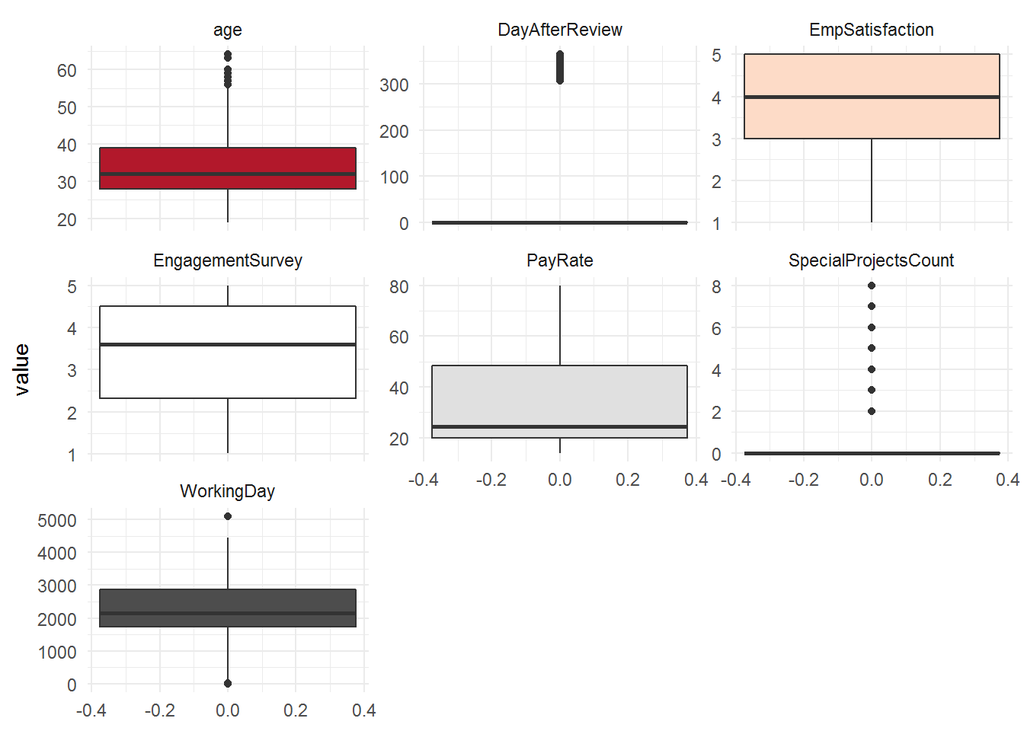

```r
hrd_clean %>%
   select_if(is.numeric) %>%
   pivot_longer(cols = c(names(.))) %>%
   ggplot(aes(y = value)) +
   geom_boxplot(aes(fill = name),show.legend = F) +
   scale_fill_brewer(palette = "RdGy") +
   facet_wrap(~name,scales = "free_y") +
   theme_minimal()
```

From the plot above we know that `age`, `DayAfterReview`,`SpecialProjectsCount` and `WorkingDay` have some outlier. We also can find that using biplot. Biplot help us visualize lots of numeric variables into two dimensions. Each axis are represented by PC. PC or Principal Componets is the summarization of every scaled numeric variables. Each variabels has different contribution to each PC. In short, PCA help us to reduce dimensionality by summarise numeric variables.

Let’s create the PCA

```r
factor <- which(sapply(hrd_clean, is.factor))

pca <- PCA(hrd_clean %>% `rownames<-`(hrd_clean$Employee_Name),
           quali.sup = c(1,7,13,14,24,26,factor),scale.unit = T,graph = F)
summary(pca)
```

```
##
## Call:
## PCA(X = hrd_clean %>% `rownames<-`(hrd_clean$Employee_Name),
##      scale.unit = T, quali.sup = c(1, 7, 13, 14, 24, 26, factor),
##      graph = F)
##
##
## Eigenvalues
##                        Dim.1   Dim.2   Dim.3   Dim.4   Dim.5   Dim.6
## Variance               1.500   1.144   1.007   0.934   0.921   0.494
## % of var.             25.006  19.066  16.783  15.568  15.350   8.226
## Cumulative % of var.  25.006  44.072  60.856  76.424  91.774 100.000
##
## Individuals (the 10 first)
##                          Dist    Dim.1    ctr   cos2    Dim.2    ctr   cos2
## Gonzalez, Maria      |  2.001 |  1.530  0.048  0.585 | -0.279  0.002  0.019 |
## Cockel, James        |  2.318 | -1.321  0.036  0.325 |  1.157  0.036  0.249 |
## Bunbury, Jessica     |  2.737 |  0.729  0.011  0.071 | -0.331  0.003  0.015 |
## Buck, Edward         |  2.116 |  0.551  0.006  0.068 |  0.469  0.006  0.049 |
## Jacobi, Hannah       |  2.444 | -0.947  0.019  0.150 |  0.239  0.002  0.010 |
## Riordan, Michael     |  3.745 |  0.346  0.002  0.009 |  0.376  0.004  0.010 |
## Ferguson, Susan      |  3.199 | -0.436  0.004  0.019 | -2.586  0.181  0.653 |
## Albert, Michael      |  2.365 |  0.659  0.009  0.078 | -0.770  0.016  0.106 |
## Gentry, Mildred      |  1.850 | -0.815  0.014  0.194 | -0.483  0.006  0.068 |
## Onque, Jasmine       |  2.448 |  0.752  0.012  0.094 |  0.007  0.000  0.000 |
##                       Dim.3    ctr   cos2
## Gonzalez, Maria       0.325  0.003  0.026 |
## Cockel, James        -1.309  0.053  0.319 |
## Bunbury, Jessica     -1.634  0.082  0.357 |
## Buck, Edward         -0.688  0.015  0.106 |
## Jacobi, Hannah       -1.521  0.071  0.387 |
## Riordan, Michael      2.765  0.235  0.545 |
## Ferguson, Susan      -1.460  0.065  0.208 |
## Albert, Michael       1.095  0.037  0.215 |
## Gentry, Mildred       0.525  0.008  0.081 |
## Onque, Jasmine        1.438  0.064  0.345 |
##
## Variables
##                         Dim.1    ctr   cos2    Dim.2    ctr   cos2    Dim.3
## PayRate              |  0.841 47.177  0.708 |  0.145  1.825  0.021 |  0.089
```

[output cut: 21 more lines]

```
## Adams, Gabriel       |  2.337 | -0.726  0.096 -0.592 | -1.388  0.353 -1.298 |
## Adams, Karma         |  0.944 | -0.823  0.760 -0.672 |  0.379  0.161  0.354 |
## Adinolfi, Wilson  K  |  2.138 | -1.244  0.339 -1.016 |  1.656  0.600  1.548 |
## Adkins, Jonathan     |  2.231 |  0.562  0.063  0.459 |  0.148  0.004  0.139 |
##                       Dim.3   cos2 v.test
## Abbott, Harley       -0.917  0.153 -0.914 |
## Abbott, Kendal        1.065  0.212  1.061 |
## Abbott, Marvin       -0.239  0.012 -0.238 |
## Acevedo, Ciara        0.058  0.001  0.057 |
## Acosta, Jaylen        0.550  0.175  0.548 |
## Acosta, Michael      -0.705  0.080 -0.703 |
## Adams, Gabriel        1.100  0.221  1.096 |
## Adams, Karma          0.112  0.014  0.112 |
## Adinolfi, Wilson  K  -0.030  0.000 -0.030 |
## Adkins, Jonathan     -0.223  0.010 -0.222 |
```

By only using 3 PC, we already covers 60% variance of actual data. Let’s draw some biplot

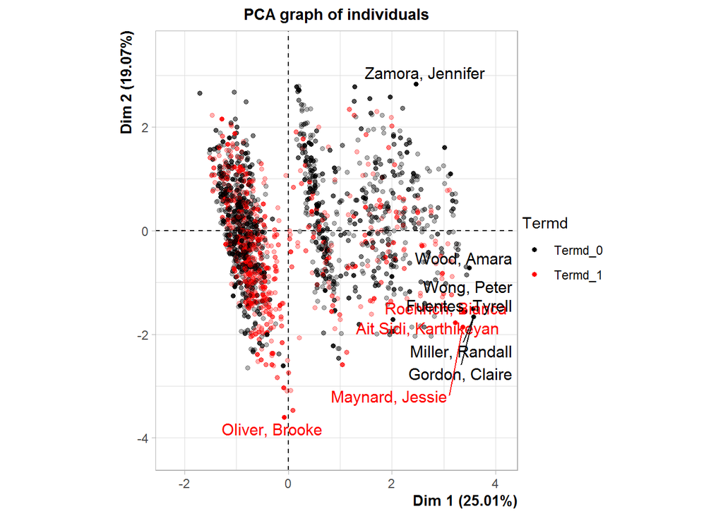

```r
plot.PCA(pca,choix = "ind",invisible = "quali",select = "contrib10",habillage = 4)
```

Even tough its kinda messy, we found 10 employee name that are considered as outliers. But remember this plot only represent approximately 44% variance of the actual data. In which variabel those employee are considered as outlier? let’s see how the variables contribute to each PC

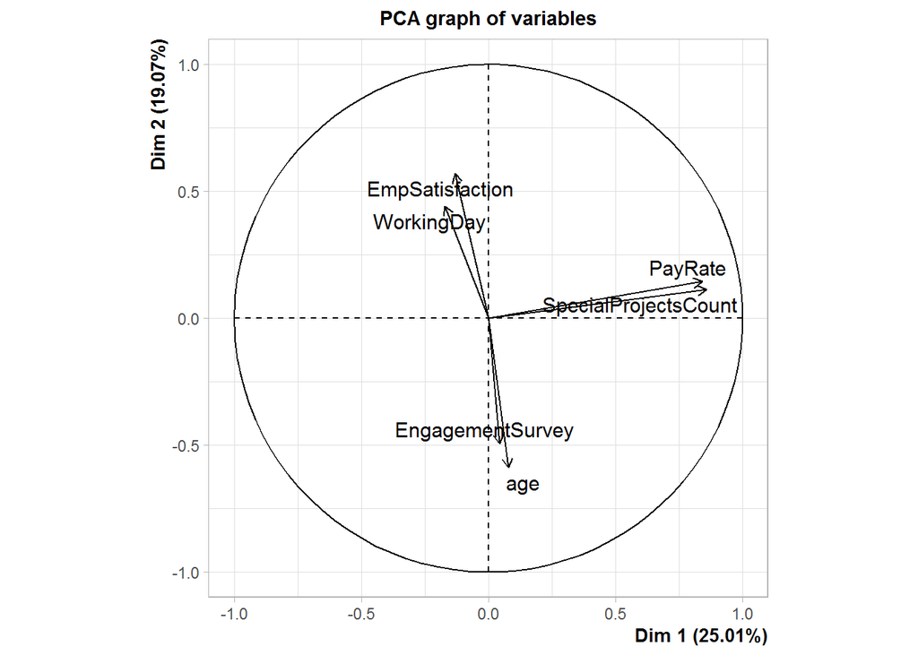

```r
plot.PCA(pca,choix = "var")
```

PC 1 or Dimension 1 is mostly contributed by `PayRate` and `SpecialProjectsCount`. Dim 2 is contributed by the other. From both plot, if the observation is placed to the most right, they have high `PayRate` and `SpecialProjectsCount`. If they placed to the most bottom, they have high `EngagementSurvey` and `age` but low `EmpSatisfaction` and `WorkingDay`. The 10 outliers is *maybe* has high value in `SpecialProjectsCount`, `age,` and `WorkingDay`. This statement is just the same as what we found using boxplot in previous result.

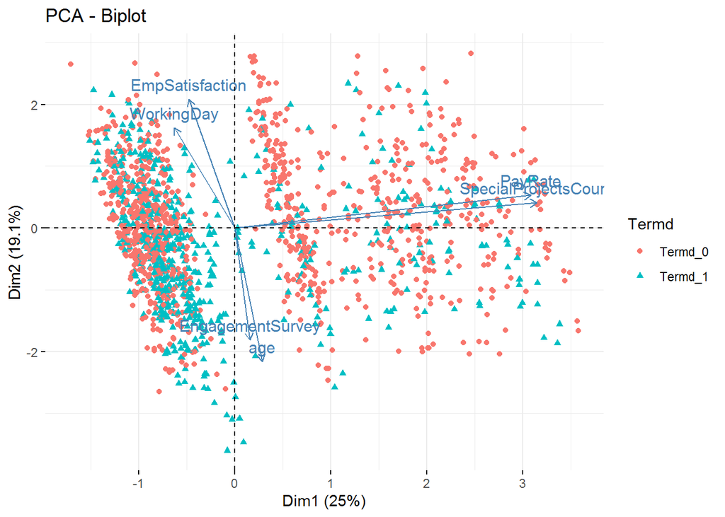

```r
fviz_pca_biplot(pca,habillage = 4,invisible = "quali",label = "var",)
```

There are lots of information we can take from the biplot above. But take it with a grain of salt because its only summarize numeric value and only covered 44% of variance. Here some insight we can take:

- PC1 is highly contributed by `PayRate` and `SpecialProjectsCount.` PC2 by `EmpSatisfaction`, `WorkingDay`, `age`, and `EngagementSurvey`
- `PayRate` and `SpecialProjectsCount` has high positive correlation
- `EngagementSurvey` and `EmpSatisfaction` has high negative correlation
- There is only slight different of contribution between `PayRate` and `SpecialProjectsCount` to PC1
- `age` and `EmpSatisfaction` has more contribution to PC2 than `WorkingDay` and `EngagementSurvey`
- Low `PayRate` and `SpecialProjectsCount` may affect the employee attrition

### 2.3.2 Is there any correlation between who a person works for and their performance score?

Employee’ manager and their performance score are portrayed in `ManagerName` and `PerformanceScore` column. We can’t calculate correlation from categorical data but we can know if the data is dependent to each other by use statistical test named chi-square test of independence. This can be done using `chisq.test()` function.

```r
chisq.test(hrd_clean$ManagerName,hrd_clean$PerformanceScore)
```

```
##
##  Pearson's Chi-squared test
##
## data:  hrd_clean$ManagerName and hrd_clean$PerformanceScore
## X-squared = 826.79, df = 60, p-value < 0.00000000000000022
```

To interpret the output, we first need to determine the null and alternative hypothesis

H0 = there is no relationship between Manager and employee performance score  
H1 = There is a relationship bertween manager and employee performance score

From the output we know that p-value is less than the alpha (we use the most common alpha, 0.95), thus we need to reject the null hypthesis (H0) and we conclude that **There is a significant relationship bertween manager and employee perfornamce score**. We know that both column is associated to each other.

We already answer the question, should we stop here? No. EDA is the space of data visualization in data science workflow. Draw your best visualization here to inform people interesting things about the data

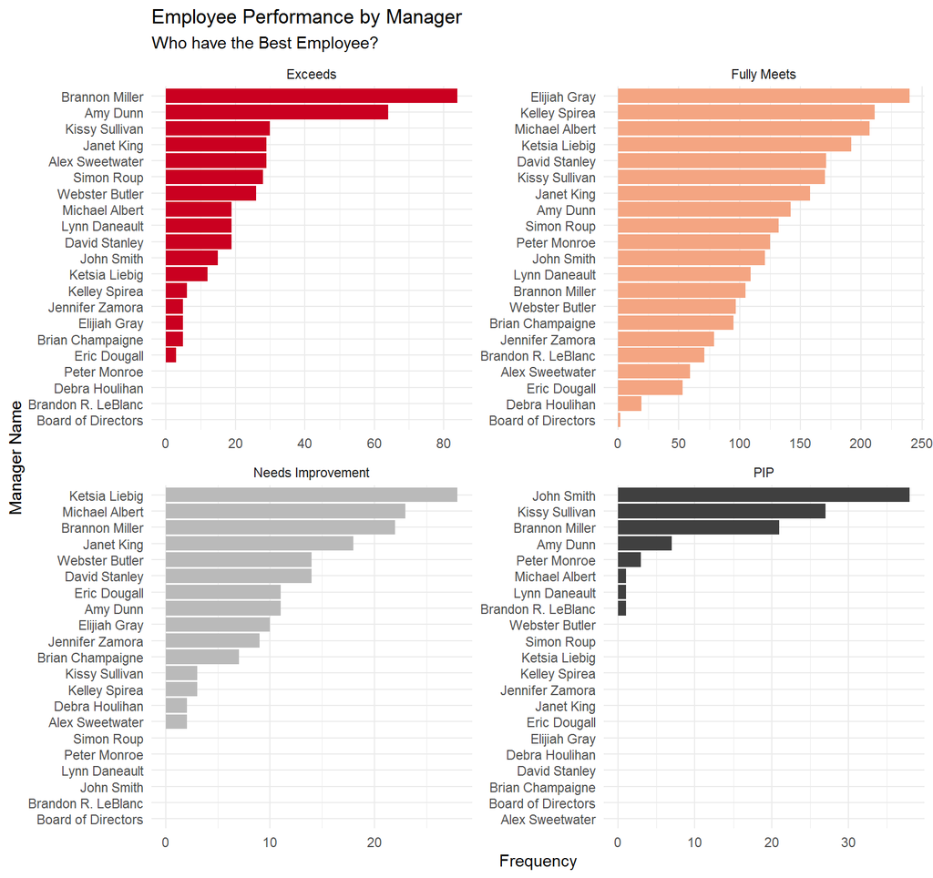

```r
# i found out there are empty factor level in some columns. we need to remove that level
hrd_clean <- hrd_clean %>%
   droplevels()

table(hrd_clean$ManagerName,hrd_clean$PerformanceScore) %>%
   as.data.frame() %>%
   mutate(Var1 = reorder_within(Var1,by = Freq,within = Var2)) %>%
   ggplot(aes(x = Freq, y = Var1)) +
   geom_col(aes(fill = Var2)) +
   scale_fill_brewer(palette = "RdGy") +
   facet_wrap(~Var2,scales = "free") +
   scale_y_reordered() +
   labs(title = "Employee Performance by Manager",
        subtitle = "Who have the Best Employee?",
        x = "Frequency", y = "Manager Name") +
   theme_minimal() +
   theme(legend.position = "none")
```

The plot above show frequency of employee that have specific performance score by each manager. “Exceeds” is the best level performance and “PIP” is the lowest. We know that Brannon Miller is the best manager because he has the highest number of great employee, in contrast, John Smith is the worst.

But is this plot enough to tell what is happening between employee and its manager relation to their performance score? I think its not. Maybe Brannon Miller has so many employee that if we calcluate by frequency he looks as the best.

```r
# showing the number of rows per manager
hrd_clean %>%
   group_by(ManagerName) %>%
   count() %>%
   arrange(-n)
```

| ManagerName | n |
| --- | --- |
| Elijiah Gray | 255 |
| Michael Albert | 250 |
| Brannon Miller | 232 |
| Ketsia Liebig | 232 |
| Kissy Sullivan | 230 |
| Amy Dunn | 224 |
| Kelley Spirea | 220 |
| Janet King | 205 |
| David Stanley | 204 |
| John Smith | 174 |

[output cut: 11 more lines]

Is now clear that Brannon Miller has lot of employee under its name compared to most manager. Let’s wrangle the data to see the percentage of best employee by the total of employee from each manager.

```r
manager_perf <- table(hrd_clean$ManagerName,hrd_clean$PerformanceScore) %>%
  as.data.frame() %>%
  pivot_wider(names_from = "Var2",values_from = "Freq") %>%
  mutate(perc_exceed = round( Exceeds / (Exceeds + `Fully Meets` + `Needs Improvement` + PIP),3),
         perc_pip = round(PIP/ (Exceeds + `Fully Meets` + `Needs Improvement` + PIP),3))

manager_perf
```

| Var1 | Exceeds | Fully Meets | Needs Improvement | PIP | perc_exceed | perc_pip |
| --- | --- | --- | --- | --- | --- | --- |
| Alex Sweetwater | 29 | 59 | 2 | 0 | 0.322 | 0.000 |
| Amy Dunn | 64 | 142 | 11 | 7 | 0.286 | 0.031 |
| Board of Directors | 0 | 2 | 0 | 0 | 0.000 | 0.000 |
| Brandon R. LeBlanc | 0 | 71 | 0 | 1 | 0.000 | 0.014 |
| Brannon Miller | 84 | 105 | 22 | 21 | 0.362 | 0.091 |
| Brian Champaigne | 5 | 95 | 7 | 0 | 0.047 | 0.000 |
| David Stanley | 19 | 171 | 14 | 0 | 0.093 | 0.000 |
| Debra Houlihan | 0 | 19 | 2 | 0 | 0.000 | 0.000 |
| Elijiah Gray | 5 | 240 | 10 | 0 | 0.020 | 0.000 |
| Eric Dougall | 3 | 53 | 11 | 0 | 0.045 | 0.000 |

[output cut: 11 more lines]

The table above is the result of our aggregation. Now we have the information about each manager’ employee performance and its percentage. Let’s draw a plot about it

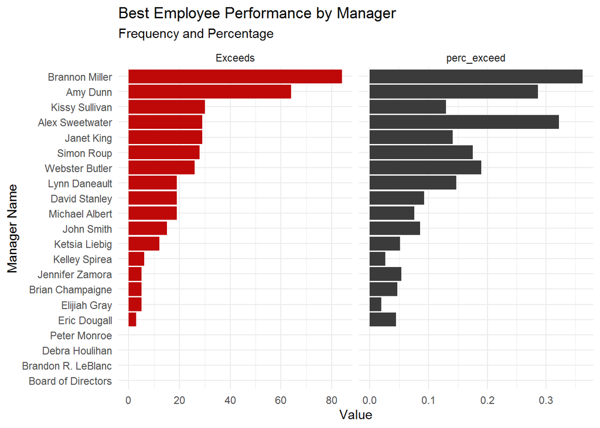

```r
manager_perf %>%
   select(c(Var1,Exceeds,perc_exceed)) %>%
   pivot_longer(cols = c(Exceeds,perc_exceed)) %>%
   ggplot(aes(x = value, y = reorder(Var1,value))) +
   geom_col(aes(fill = name),show.legend = F) +
   scale_fill_manual(values = c("#bf0808","#3b3b3b")) +
   facet_wrap(~name,scales = "free_x") +
   labs(title = "Best Employee Performance by Manager",
        subtitle = "Frequency and Percentage",
        x = "Value", y = "Manager Name") +
   theme_minimal()
```

Now is true that Brannon Miller is the best Manager because not only by frequency of high performanced employee, but also by percentage. More than 30% of his employee has high performance. But we also know that Amy Dunn, the second best, is not actually the second best. Alex Sweetwater is better than her by percentage of their employee. With this type of information we can draw a correct conclussion because the calculation is balanced. Is important to share information that is the most true, rather than we ‘want’.

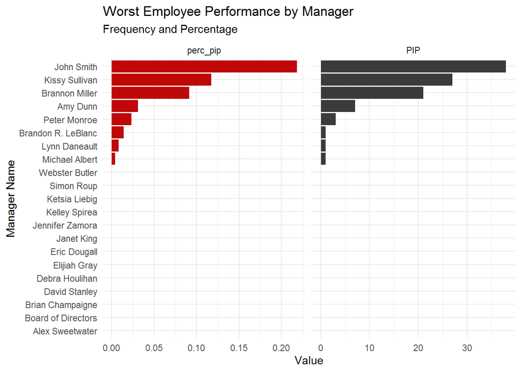

```r
manager_perf %>%
   select(c(Var1,PIP,perc_pip)) %>%
   pivot_longer(cols = c(PIP,perc_pip)) %>%
   ggplot(aes(x = value, y = reorder(Var1,value))) +
   geom_col(aes(fill = name),show.legend = F) +
   scale_fill_manual(values = c("#bf0808","#3b3b3b")) +
   facet_wrap(~name,scales = "free_x") +
   labs(title = "Worst Employee Performance by Manager",
        subtitle = "Frequency and Percentage",
        x = "Value", y = "Manager Name") +
   theme_minimal()
```

### 2.3.3 Is there any inequality in the company based on its pay rate? are there some departments that are paid more?

```r
hrd_clean %>%
  group_by(Department) %>%
  summarise(avg_PayRate = mean(PayRate),
            median_PayRate = median(PayRate),
            min_PayRate = min(PayRate),
            max_PayRate = max(PayRate)) %>%
   arrange(-median_PayRate)
```

| Department | avg_PayRate | median_PayRate | min_PayRate | max_PayRate |
| --- | --- | --- | --- | --- |
| Sales | 54.99021 | 55.00 | 25.00 | 65 |
| Software Engineering | 51.66522 | 52.25 | 27.00 | 62 |
| Executive Office | 51.85417 | 47.00 | 27.00 | 80 |
| IT/IS | 46.38903 | 45.00 | 21.00 | 65 |
| Admin Offices | 36.01150 | 29.00 | 16.56 | 62 |
| Production | 23.61290 | 21.00 | 14.00 | 80 |

From the aggregation result we know `Production` department has the lowest average and median compated to other department, the median is not even a half of 4 highest payrate median. We know every department have different workload and there are always other factors that affect the salary. So we can’t directly say that there is an equality in `payRate` in different departments. We can get better insight if we analyze the `payRate` by each department

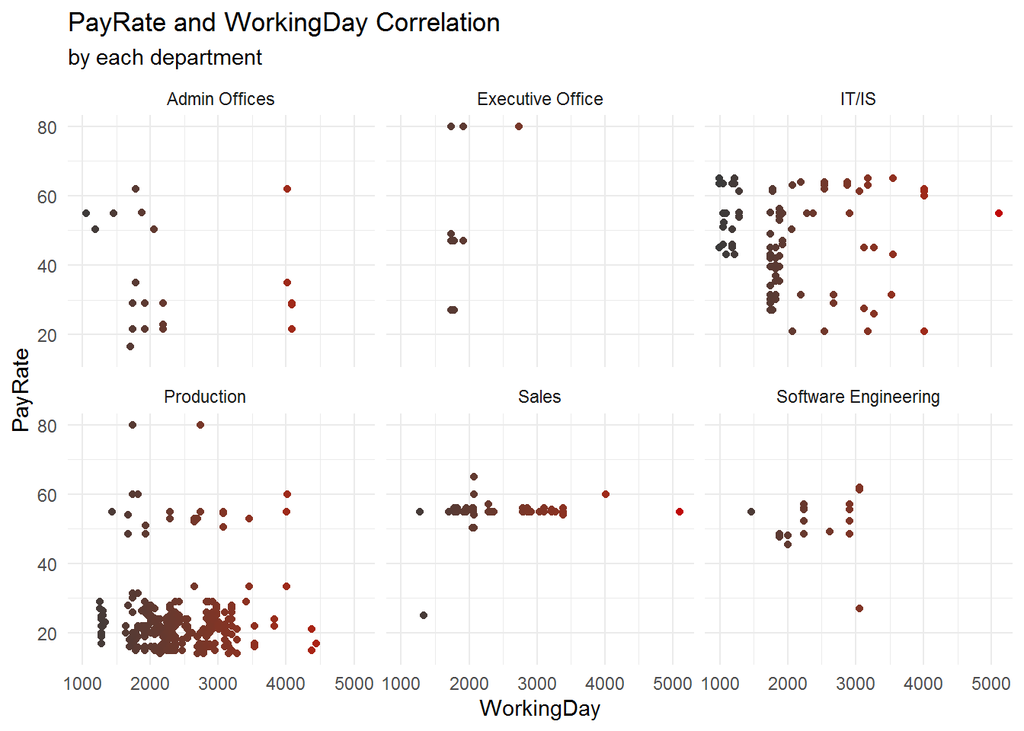

```r
hrd_clean %>%
   filter(Termd == 0) %>%
   select(PayRate,Department,WorkingDay) %>%
   ggplot(aes(x = WorkingDay, y = PayRate)) +
   geom_point(aes(col = WorkingDay),show.legend = F) +
   scale_color_continuous(low = "#3b3b3b",high = "#bf0808") +
   facet_wrap(~Department) +
   labs(title = "PayRate and WorkingDay Correlation",
        subtitle = "by each department") +
   theme_minimal()
```

Its a common knowledge that the longer employee work in same company, the higher the salary. But from the plot above, for every department, there is no correlation between `WorkingDay` and `PayRate`.

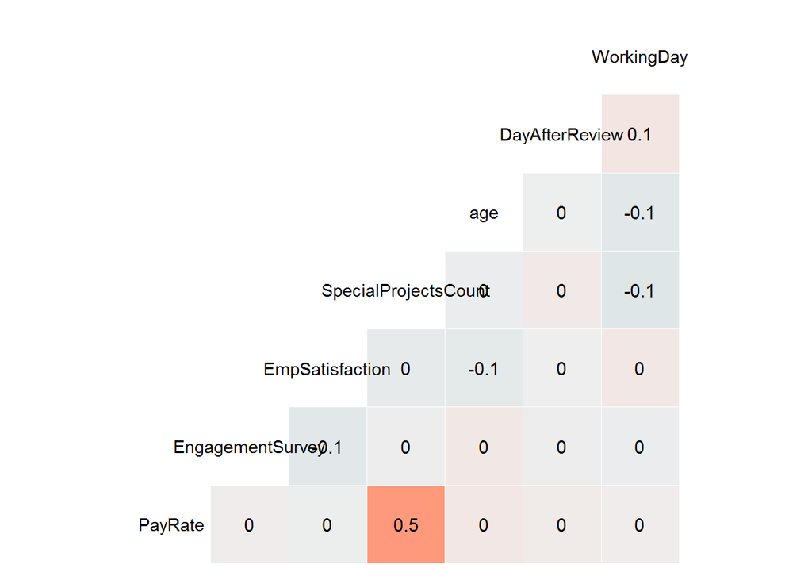

```r
GGally::ggcorr(hrd_clean %>%
                 select_if(is.numeric),label = T,legend.position = "none")
```

```r
cor.test(hrd_clean$PayRate,hrd_clean$SpecialProjectsCount)
```

```
##
##  Pearson's product-moment correlation
##
## data:  hrd_clean$PayRate and hrd_clean$SpecialProjectsCount
## t = 31.591, df = 3230, p-value < 0.00000000000000022
## alternative hypothesis: true correlation is not equal to 0
## 95 percent confidence interval:
##  0.4590573 0.5117513
## sample estimates:
##       cor
## 0.4858456
```

```r
hrd_clean %>%
  group_by(Department) %>%
  summarise(total = sum(SpecialProjectsCount),
            avg = mean(SpecialProjectsCount)) %>%
   arrange(-avg)
```

| Department | total | avg |
| --- | --- | --- |
| IT/IS | 2917 | 5.55619048 |
| Software Engineering | 479 | 4.16521739 |
| Executive Office | 87 | 3.62500000 |
| Admin Offices | 253 | 3.16250000 |
| Sales | 65 | 0.19578313 |
| Production | 95 | 0.04406308 |

IT/IS department has the most `SpecialProjectsCount`, every employee in that department has 5 `SpecialProjectsCount` in average. We can assume that people in IT/IS department is most likely get higher `payRate` **because** they recieve more Special Projects. Sales, however, has low average of special projects but they have the highest of `payRate` median.

# 3 Modeling

Our data has a lot of variables, 27 in total. Not all variabels are important to use in modeling step. We can remove some by identifying which variables has low variance, or subjectively select the variables

```r
zero_var <- nearZeroVar(hrd_clean)
zero_var
```

```
## [1]  6 10 14 24 26
```

`nearZeroVar()` function return column index that has low (or near to zero) variance. Low variance data is bad to our model because there is not much information the model can learn. Next we use the index to subset to our data

```r
hrd_mod <- hrd_clean[,-zero_var]
head(hrd_mod)
```

|  | Employee_Name | FromDiversityJobFairID | PayRate | Termd | Position | DOB | Sex | MaritalDesc | HispanicLatino | RaceDesc | DateofHire | TermReason | EmploymentStatus | Department | ManagerName | RecruitmentSource | PerformanceScore | EngagementSurvey | EmpSatisfaction | SpecialProjectsCount | age | WorkingDay |
| --- | --- | --- | --- | --- | --- | --- | --- | --- | --- | --- | --- | --- | --- | --- | --- | --- | --- | --- | --- | --- | --- | --- |
| 1 | Gonzalez, Maria | 0 | 39 | 0 | IT Support | 1981-04-16 | F | Separated | Yes | White | 2015-01-05 | N/A - still employed | Active | IT/IS | Peter Monroe | Employee Referral | Fully Meets | 4.61 | 4 | 5 | 34 | 1822 |
| 2 | Cockel, James | 0 | 15 | 0 | Production Technician I | 1977-09-08 | M | Single | No | White | 2013-07-08 | N/A - still employed | Active | Production | David Stanley | Employee Referral | Fully Meets | 1.51 | 5 | 0 | 36 | 2368 |
| 3 | Bunbury, Jessica | 0 | 55 | 1 | Area Sales Manager | 1964-06-01 | F | Married | No | Black or African American | 2011-08-15 | Another position | Voluntarily Terminated | Sales | John Smith | Social Networks - Facebook Twitter etc | Fully Meets | 3.14 | 5 | 0 | 47 | 1083 |
| 4 | Buck, Edward | 0 | 55 | 0 | Area Sales Manager | 1975-07-07 | M | Married | No | White | 2014-09-29 | N/A - still employed | Active | Sales | Lynn Daneault | Employee Referral | Fully Meets | 3.31 | 5 | 0 | 39 | 1920 |
| 5 | Jacobi, Hannah | 0 | 21 | 0 | Production Technician I | 1966-03-22 | F | Divorced | No | White | 2013-09-30 | N/A - still employed | Active | Production | Kissy Sullivan | Employee Referral | Fully Meets | 2.05 | 5 | 0 | 48 | 2284 |
| 6 | Riordan, Michael | 0 | 55 | 0 | Area Sales Manager | 1968-01-15 | M | Separated | No | White | 2006-01-09 | N/A - still employed | Active | Sales | Lynn Daneault | Billboard | Exceeds | 4.10 | 3 | 0 | 38 | 5105 |

Actually, our data still has some redundant information. For example, `TermReason` describe why employees are resign, same as `EmploymentStatus`. We will remove that kind of variables and also date and id variables

```r
hrd_mod <- hrd_mod %>%
   select(-c(Employee_Name,DOB,DateofHire,TermReason,EmploymentStatus,WorkingDay))

head(hrd_mod)
```

|  | FromDiversityJobFairID | PayRate | Termd | Position | Sex | MaritalDesc | HispanicLatino | RaceDesc | Department | ManagerName | RecruitmentSource | PerformanceScore | EngagementSurvey | EmpSatisfaction | SpecialProjectsCount | age |
| --- | --- | --- | --- | --- | --- | --- | --- | --- | --- | --- | --- | --- | --- | --- | --- | --- |
| 1 | 0 | 39 | 0 | IT Support | F | Separated | Yes | White | IT/IS | Peter Monroe | Employee Referral | Fully Meets | 4.61 | 4 | 5 | 34 |
| 2 | 0 | 15 | 0 | Production Technician I | M | Single | No | White | Production | David Stanley | Employee Referral | Fully Meets | 1.51 | 5 | 0 | 36 |
| 3 | 0 | 55 | 1 | Area Sales Manager | F | Married | No | Black or African American | Sales | John Smith | Social Networks - Facebook Twitter etc | Fully Meets | 3.14 | 5 | 0 | 47 |
| 4 | 0 | 55 | 0 | Area Sales Manager | M | Married | No | White | Sales | Lynn Daneault | Employee Referral | Fully Meets | 3.31 | 5 | 0 | 39 |
| 5 | 0 | 21 | 0 | Production Technician I | F | Divorced | No | White | Production | Kissy Sullivan | Employee Referral | Fully Meets | 2.05 | 5 | 0 | 48 |
| 6 | 0 | 55 | 0 | Area Sales Manager | M | Separated | No | White | Sales | Lynn Daneault | Billboard | Exceeds | 4.10 | 3 | 0 | 38 |

Before modeling is important to split the data into train and test data. The train data will be used for train the model and test data to evaluate our model. We also need to check if the target variable is balanced.

## 3.1 Splitting

```r
prop.table(table(hrd_mod$Termd))
```

```
##
##         0         1
## 0.6704827 0.3295173
```

The data is not balance. After we split the data, we need to balance it using downsample or upsample

```r
set.seed(123)
splitter <- initial_split(hrd_mod,prop = 0.8,strata = "Termd")
train <- training(splitter)
test <- testing(splitter)
```

```r
prop.table(table(train$Termd))
```

```
##
##         0         1
## 0.6702744 0.3297256
```

upsampling will duplicate the minority until the data is balanced, in contrast, downsampling will remove the majority. Since the data is not that extreme unbalanced, i’ll use downsampling.

```r
train_down <- downSample(train %>% select(-Termd), train$Termd)
# downSample() function rename Termd into Class.
# lets rename it again and check the class probability
train_down <- train_down %>%
   rename("Termd" = "Class") %>%
   droplevels()
prop.table(table(train_down$Termd))
```

```
##
##   0   1
## 0.5 0.5
```

Now the train data is balanced and we’re ready to do modeling. Since most ouf our data is categorical, i’ll focus on building tree based model. i also will use default parameter when building the model. Parameter tuning deserve its own part

## 3.2 Decision Tree

```r
library(partykit)
#mod_dt <- ctree(Termd ~., data = train_down)

# it will take times everytime we fit the data
# i save the trained model and we only need to load it
mod_dt <- readRDS("model/mod_dt.rds")

# predict to test data
pred_dt <- predict(mod_dt,test,type = "prob")
head(data.frame(pred_dt))
```

|  | X0 | X1 |
| --- | --- | --- |
| 10 | 1.0000000 | 0.0000000 |
| 12 | 1.0000000 | 0.0000000 |
| 13 | 0.8275862 | 0.1724138 |
| 16 | 0.4545455 | 0.5454545 |
| 20 | 0.4824561 | 0.5175439 |
| 23 | 0.2213115 | 0.7786885 |

Notice that i set the output predict as probability rather than class. We can always change the treshold to decide which class the prediction results in. For now, we will use 0.5 as the common trehsold standard

```r
pred_dt_class <- as.factor(ifelse(pred_dt[,1] > 0.5,0,1))
conf_dt <- confusionMatrix(pred_dt_class,test$Termd,positive = "0")
conf_dt
```

```
## Confusion Matrix and Statistics
##
##           Reference
## Prediction   0   1
##          0 277  47
##          1 156 165
##
##                Accuracy : 0.6853
##                  95% CI : (0.6479, 0.721)
##     No Information Rate : 0.6713
##     P-Value [Acc > NIR] : 0.2388
##
##                   Kappa : 0.3695
##
##  Mcnemar's Test P-Value : 0.00000000000003453
##
##             Sensitivity : 0.6397
##             Specificity : 0.7783
##          Pos Pred Value : 0.8549
##          Neg Pred Value : 0.5140
##              Prevalence : 0.6713
##          Detection Rate : 0.4295
##    Detection Prevalence : 0.5023
##       Balanced Accuracy : 0.7090
##
##        'Positive' Class : 0
##
```

Confusion matrix show us a lot of stuff. In the most common way to decide if the model is good enough is to look at the accuracy. we have 68.5% accuracy, is it good enough? Is accuracy the only important metrics in classification? To understand this lets take a short break to learn about confusion matrix

### 3.2.1 confusion matrix

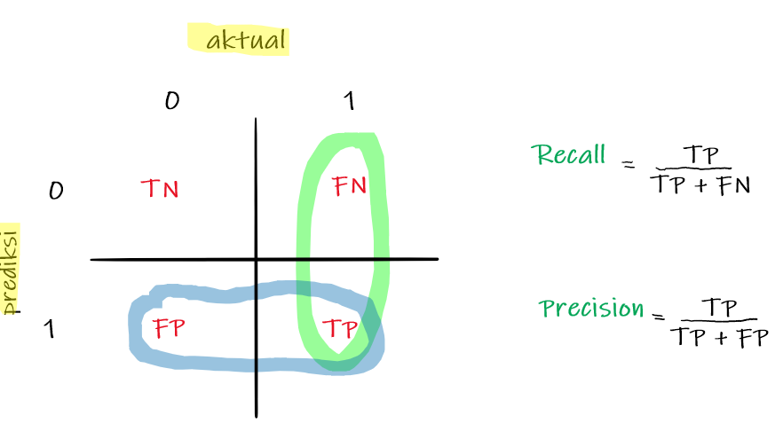

If 1 is the positive value Confusion matrix consist in 4 parts: - True Positive (TP): When we predict 1, the actual value is 1 - True Negative (TN): When we predict 0, the actual value is 0 - False Postive (FP): When we predict 1, the actual value is 0 - False Negative (FN): When we predict 0, the actual value is 1

Recall and precision is most common metrics beside accuracy that take FP or FN into account. They consider the weight of FP or FN and have interesting intepretation depends on the case

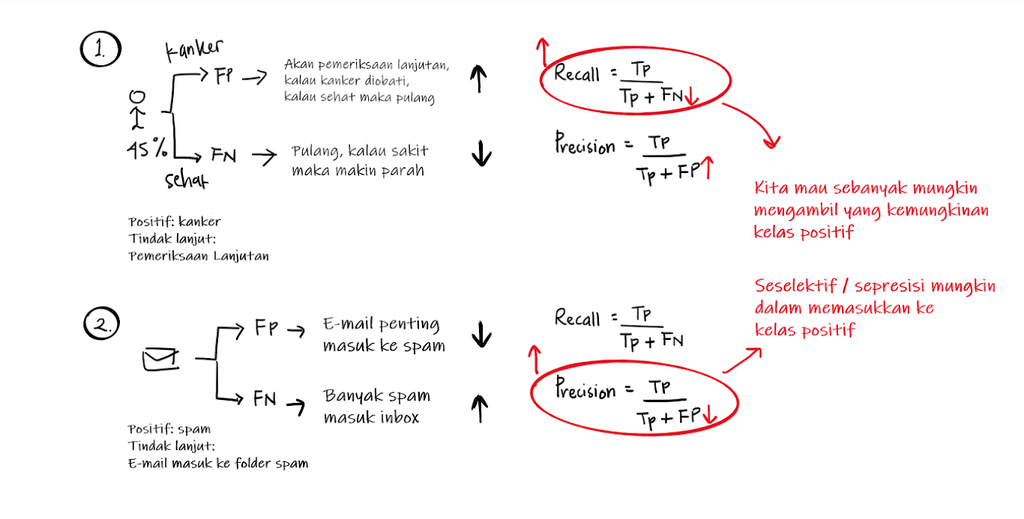

The image above show some example of the case. In our case, is important to know which employee is likely to resign as far as we can so the HR department can do some action to prevent that. The cost if employees are resign is higher than if we do some precautionary action. Thus, **it is okay if we do the action to employee who doesn’t want to resign but predicted to resign rather than actually missed someone who will resign before we do the action**. In confusion matrix terms, it simply means we need to avoid high False Negative (when employees are predicted to not resign, but actually does). In summary, we want high Recall value

## 3.3 Random Forest

```r
# mod_rf <- rand_forest(mode = "classification") %>%
#   set_engine("ranger") %>%
#   fit(Termd ~., data = train_down)

mod_rf <- readRDS("model/mod_rf.rds")
```

```r
pred_rf <- predict(mod_rf,test,type = "prob")
pred_rf_class <- as.factor(ifelse(pred_rf$.pred_0 >0.5, 0,1))

conf_rf <- confusionMatrix(pred_rf_class,test$Termd,positive = "0")
conf_rf
```

```
## Confusion Matrix and Statistics
##
##           Reference
## Prediction   0   1
##          0 370  19
##          1  63 193
##
##                Accuracy : 0.8729
##                  95% CI : (0.8447, 0.8976)
##     No Information Rate : 0.6713
##     P-Value [Acc > NIR] : < 0.00000000000000022
##
##                   Kappa : 0.7264
##
##  Mcnemar's Test P-Value : 0.000002049
##
##             Sensitivity : 0.8545
##             Specificity : 0.9104
##          Pos Pred Value : 0.9512
##          Neg Pred Value : 0.7539
##              Prevalence : 0.6713
##          Detection Rate : 0.5736
##    Detection Prevalence : 0.6031
##       Balanced Accuracy : 0.8824
##
##        'Positive' Class : 0
##
```

## 3.4 Xgboost

```r
# mod_xgb <- boost_tree(mode = "classification") %>%
#   set_engine("xgboost") %>%
#   fit(Termd~., data = train_down)

mod_xgb <- readRDS("model/mod_xgb.rds")
```

```r
pred_xgb <- predict(mod_xgb,test,type = "prob")
pred_xgb_class <- as.factor(ifelse(pred_xgb$.pred_0 > 0.5, 0,1))
conf_xgb <- confusionMatrix(pred_xgb_class,test$Termd,positive = "0")
conf_xgb
```

```
## Confusion Matrix and Statistics
##
##           Reference
## Prediction   0   1
##          0 337  33
##          1  96 179
##
##                Accuracy : 0.8
##                  95% CI : (0.767, 0.8302)
##     No Information Rate : 0.6713
##     P-Value [Acc > NIR] : 0.0000000000002696
##
##                   Kappa : 0.5787
##
##  Mcnemar's Test P-Value : 0.0000000479375186
##
##             Sensitivity : 0.7783
##             Specificity : 0.8443
##          Pos Pred Value : 0.9108
##          Neg Pred Value : 0.6509
##              Prevalence : 0.6713
##          Detection Rate : 0.5225
##    Detection Prevalence : 0.5736
##       Balanced Accuracy : 0.8113
##
##        'Positive' Class : 0
##
```

lets draw a table and conclude our modeling result

```r
data.frame(accuracy = c(conf_dt$overall[1],conf_rf$overall[1],conf_xgb$overall[1]),
           recall = c(conf_dt$byClass[3],conf_rf$byClass[3],conf_xgb$byClass[3])) %>%
   `rownames<-`(c("Decision Tree","Random Forest","XGBoost")) %>%
   arrange(-recall)
```

|  | accuracy | recall |
| --- | --- | --- |
| Random Forest | 0.8728682 | 0.9511568 |
| XGBoost | 0.8000000 | 0.9108108 |
| Decision Tree | 0.6852713 | 0.8549383 |

# 4 Model Tuning

The model evaluation is quite good already. But we can always maximize the result by doing hyperparameter tuning. In short, hyperparameter tuning is choosing a set of optimal hyperparameter for a learning algorithm. We will provide set of value to every model’ parameter and fit the model. We will take parameter value from the best fitting model. Since Decision Tree result is way lower than Random Forest or XGBoost, we will not tune the model and focusing only to the best 2.

set k-fold cross validation

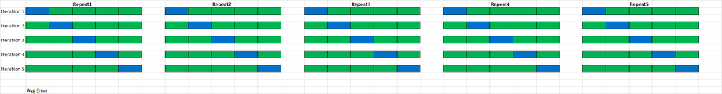

```r
set.seed(123)
folds <- vfold_cv(train_down,5,strata = "Termd")
```

## 4.1 Random Forest

we will tune the `mtry` and `trees` parameter using grid tuning. this process will take a lot of time because it will train all possible parameter combination and extract the best result. we will aim the highest recall and ROC as our best model.

```r
# trees and mtry grid combination
rf.grid <- expand.grid(trees = seq(500,700,50), mtry = 4:8)

# model setup. random forest using ranger engine where the trees and mtry
# will be changed by its grid
rf.setup <- rand_forest(trees = tune(), mtry = tune()) %>%
  set_engine("ranger",importance = "impurity") %>%
  set_mode("classification")

# formula workflow
rf.wf <- workflow() %>%
  add_model(rf.setup) %>%
  add_recipe(recipe(Termd ~.,data = train_down,skip = T))

# fit the data to model workflow
# rf.tune <- tune_grid(rf.wf,resamples = folds,grid = rf.grid,
#                      metrics = metric_set(accuracy,recall,roc_auc))
```

```r
rf.tune <- readRDS("model/rf_tune.rds")
show_best(rf.tune,metric = "recall")
```

| mtry | trees | .metric | .estimator | mean | n | std_err | .config |
| --- | --- | --- | --- | --- | --- | --- | --- |
| 8 | 500 | recall | binary | 0.8933196 | 5 | 0.007020363 | Model21 |
| 8 | 600 | recall | binary | 0.8886275 | 5 | 0.007637053 | Model23 |
| 7 | 600 | recall | binary | 0.8851187 | 5 | 0.005055479 | Model18 |
| 7 | 650 | recall | binary | 0.8850980 | 5 | 0.005494815 | Model19 |
| 8 | 700 | recall | binary | 0.8850843 | 5 | 0.006691534 | Model25 |

random forest with 8 mtry and 500 tree is the best model based on recall. we will use it as our main random forest model

```r
rf_best <- rf.wf %>%
  finalize_workflow(select_best(rf.tune,"recall")) %>%
  fit(train_down)

rf_pred_2 <- predict(rf_best,test,type = "prob")
rf_pred_class2 <- as.factor(ifelse(rf_pred_2$.pred_0 > 0.5,0,1))

conf_rf_2 <- confusionMatrix(rf_pred_class2,test$Termd)
conf_rf_2
```

```
## Confusion Matrix and Statistics
##
##           Reference
## Prediction   0   1
##          0 389  11
##          1  44 201
##
##                Accuracy : 0.9147
##                  95% CI : (0.8905, 0.9351)
##     No Information Rate : 0.6713
##     P-Value [Acc > NIR] : < 0.00000000000000022
##
##                   Kappa : 0.8142
##
##  Mcnemar's Test P-Value : 0.00001597
##
##             Sensitivity : 0.8984
##             Specificity : 0.9481
##          Pos Pred Value : 0.9725
##          Neg Pred Value : 0.8204
##              Prevalence : 0.6713
##          Detection Rate : 0.6031
##    Detection Prevalence : 0.6202
##       Balanced Accuracy : 0.9232
##
##        'Positive' Class : 0
##
```

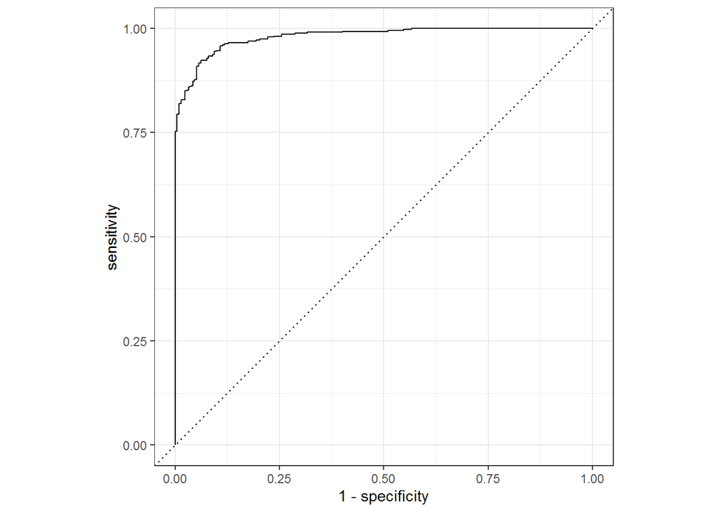

```r
cbind(rf_pred_2,rf_pred_class2,test$Termd) %>%
   setNames(c("prob_0","prob_1","pred_class","truth")) %>%
   roc_curve(truth,prob_0) %>%
   autoplot()
```

The plot above shows ROC. The ROC itself doesn’t have any value, its just portayed the tradeoff between sensitivity and 1-specificity if we change the treshold. A good ROC give curves closer to the top-left corner.

```r
cbind(rf_pred_2,rf_pred_class2,test$Termd) %>%
   setNames(c("prob_0","prob_1","pred_class","truth")) %>%
   roc_auc(truth, prob_0)
```

| .metric | .estimator | .estimate |
| --- | --- | --- |
| roc_auc | binary | 0.9807345 |

We have 0.98 AUC, that’s great! it means the ROC curve covers 98% area in the whole plot. The higher it is, the better. Next, lets do another model tuning for XGBoost

## 4.2 XGBoost

```r
xg.grid <- expand.grid(trees = seq(500,700,50), mtry = 4:8, learn_rate = c(0.1,0.01,0.005))

xg.setup <- boost_tree(trees = tune(), mtry = tune(), learn_rate = tune()) %>%
  set_engine("xgboost") %>%
  set_mode("classification")

xg.wf <- workflow() %>%
  add_formula(Termd ~ .) %>%
  add_model(xg.setup)

# xg.tune <- tune_grid(xg.wf,resamples = folds, grid = xg.grid,
#                      metrics = metric_set(accuracy,recall,roc_auc))
```

```r
xg.tune <- readRDS("model/xg_tune.rds")
show_best(xg.tune,metric = "recall")
```

| mtry | trees | learn_rate | .metric | .estimator | mean | n | std_err | .config |
| --- | --- | --- | --- | --- | --- | --- | --- | --- |
| 8 | 700 | 0.1 | recall | binary | 0.8441211 | 5 | 0.01405425 | Model75 |
| 8 | 650 | 0.1 | recall | binary | 0.8417819 | 5 | 0.01308254 | Model74 |
| 8 | 500 | 0.1 | recall | binary | 0.8382663 | 5 | 0.01248719 | Model71 |
| 8 | 600 | 0.1 | recall | binary | 0.8382663 | 5 | 0.01474745 | Model73 |
| 8 | 550 | 0.1 | recall | binary | 0.8347437 | 5 | 0.01339574 | Model72 |

The best XGBooost model is created with 8 mtry, 700 trees and 0.1 learn_rate. we will use it as our main XGBoost model

```r
xg_best <- xg.wf %>%
  finalize_workflow(select_best(xg.tune,"recall")) %>%
  fit(train_down)

xg_pred_2 <- predict(xg_best,test,type = "prob")
xg_pred_class2 <- as.factor(ifelse(xg_pred_2$.pred_0 > 0.5,0,1))

conf_xg_2 <- confusionMatrix(xg_pred_class2,test$Termd)
conf_xg_2
```

```
## Confusion Matrix and Statistics
##
##           Reference
## Prediction   0   1
##          0 360  23
##          1  73 189
##
##                Accuracy : 0.8512
##                  95% CI : (0.8213, 0.8777)
##     No Information Rate : 0.6713
##     P-Value [Acc > NIR] : < 0.00000000000000022
##
##                   Kappa : 0.6819
##
##  Mcnemar's Test P-Value : 0.0000005702
##
##             Sensitivity : 0.8314
##             Specificity : 0.8915
##          Pos Pred Value : 0.9399
##          Neg Pred Value : 0.7214
##              Prevalence : 0.6713
##          Detection Rate : 0.5581
##    Detection Prevalence : 0.5938
##       Balanced Accuracy : 0.8615
##
##        'Positive' Class : 0
##
```

The recall is slightly better than previous XGboost model but still lower than tuned random forest. Let’s draw the ROC and calculate AUC

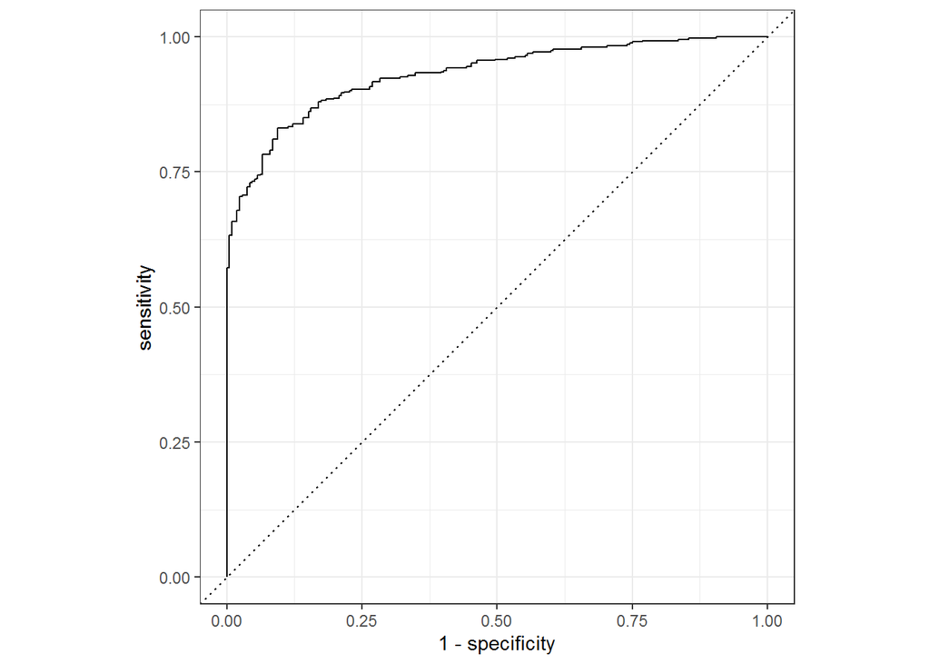

```r
cbind(xg_pred_2,xg_pred_class2,test$Termd) %>%
   setNames(c("prob_0","prob_1","pred_class","truth")) %>%
   roc_curve(truth,prob_0) %>%
   autoplot()
```

Random Forest ROC curve is slightly beter than this, the curve is closer to the top left.

```r
cbind(xg_pred_2,xg_pred_class2,test$Termd) %>%
   setNames(c("prob_0","prob_1","pred_class","truth")) %>%
   roc_auc(truth, prob_0)
```

| .metric | .estimator | .estimate |
| --- | --- | --- |
| roc_auc | binary | 0.9300024 |

Let’s summarise all the evaluation result

```r
data.frame(accuracy = c(conf_dt$overall[1],conf_rf$overall[1],conf_xgb$overall[1],
                        conf_rf_2$overall[1],conf_xg_2$overall[1]),
           recall = c(conf_dt$byClass[3],conf_rf$byClass[3],conf_xgb$byClass[3],
                      conf_rf_2$byClass[3],conf_xg_2$byClass[3])) %>%
   `rownames<-`(c("Decision Tree","Random Forest","XGBoost","RF Tuned","XGB Tuned")) %>%
   arrange(-recall)
```

|  | accuracy | recall |
| --- | --- | --- |
| RF Tuned | 0.9147287 | 0.9725000 |
| Random Forest | 0.8728682 | 0.9511568 |
| XGB Tuned | 0.8511628 | 0.9399478 |
| XGBoost | 0.8000000 | 0.9108108 |
| Decision Tree | 0.6852713 | 0.8549383 |

Now we have our desired, most accurate model to predict which employee is most likely to resign. But the downside of robust algorithm like Random Forest is the diffulcties of intepretation. Some models can be easily interpreted, such as the linear or logistic regression model and decision trees. This sometimes drive the data scientist to choose more interpretable model since they need to communicate it to their manager or higher rank, who perhaps are not familiar with machine learning. To solve this problem we need additional tools to intepret our black box model, we can use a method called Local Interpretable Model-Agnostic Explanations (LIME)

# 5 LIME for Model Intepretation

Intuitively, you can check the importance of each variable from the model based on the impurity of each variables. Variable importance quantifies the global contribution of each input variable to the predictions of a machine learning model.

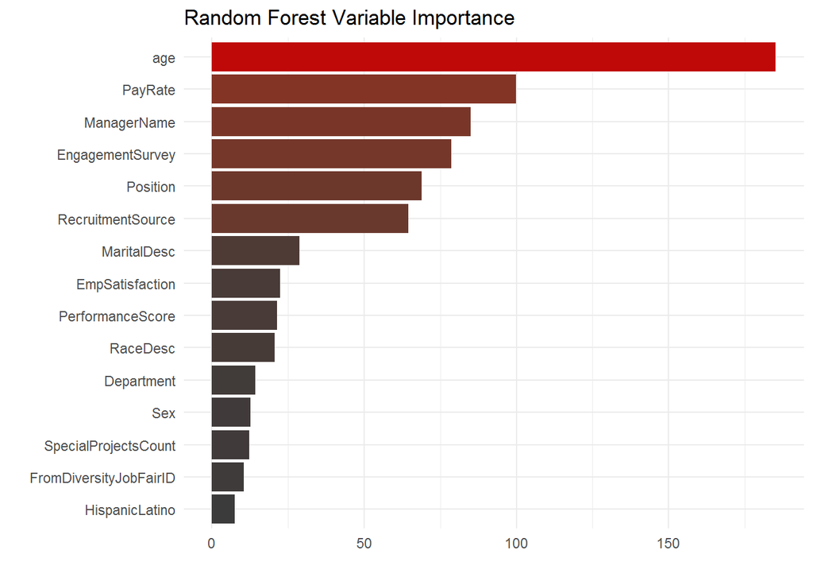

```r
tidy(rf_best$fit$fit$fit$variable.importance) %>%
   ggplot(aes(x = x, y = reorder(names,x))) +
   geom_col(aes(fill = x),show.legend = F) +
   scale_fill_continuous(low = "#3b3b3b",high = "#bf0808") +
   labs(title  = "Random Forest Variable Importance",
        x = "",y = "") +
   theme_minimal()
```

However, variable importance measures rarely give insight into the average direction that a variable affects a response function. They simply state the magnitude of a variable’s relationship with the response as compared to other variables used in the model. We can’t know specifically the influence of each factors for a single observation. That’s why we need LIME to help us understand individually what makes people resign.

**NOTE:** For learning purpose, i use non-recipe workflow when building and tuning the model. However this method is not compatible to LIME explanator. In the chunk below i recreate our model with same parameter setting as our best model. For those who want a clean way to modeling using `tidymodels`, please take a look at this [article](https://rpubs.com/David21/Tidymodels)

```r
best_setup <- rand_forest(trees = 500, mtry = 8) %>%
  set_engine("ranger",importance = "impurity") %>%
  set_mode("classification")
rf_bestx <- fit_xy(object = best_setup,x = train_down %>% select(-Termd),
                   y = train_down$Termd)
```

```r
set.seed(123)
explainer <- lime(x = train_down %>% select(-Termd),
                  model = rf_bestx)
```

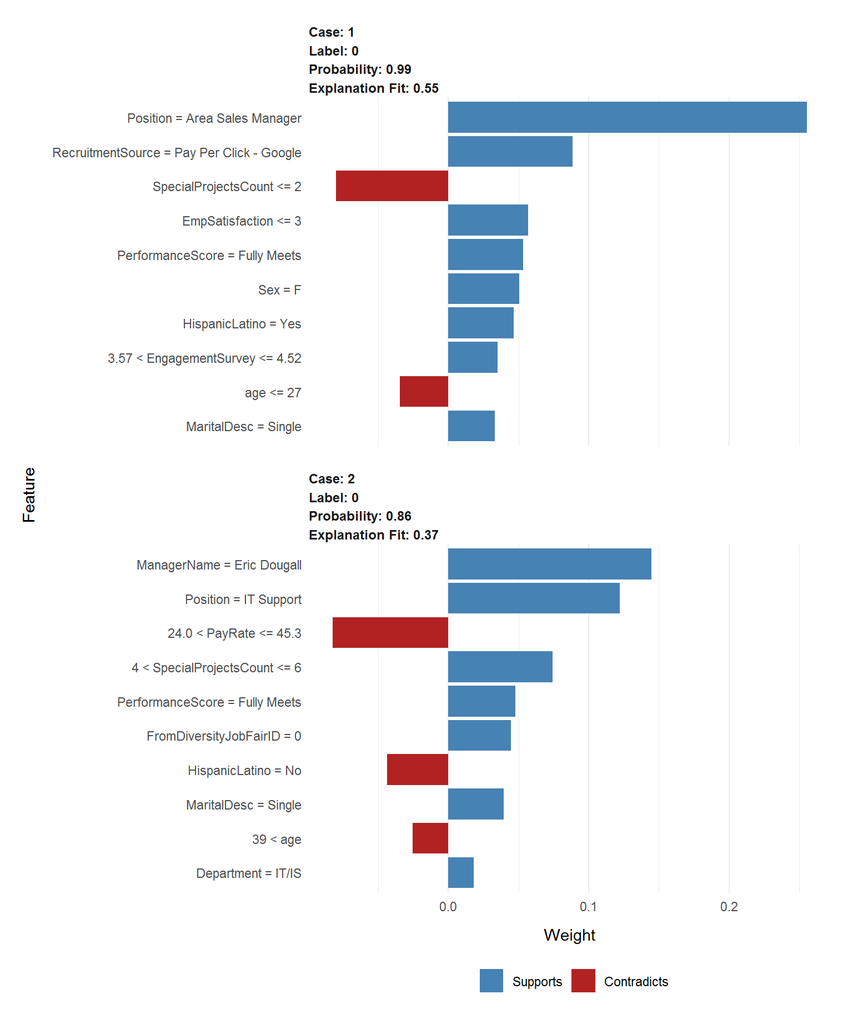

```r
explanation <- explain(x = test %>% select(-Termd) %>% slice(1:2),
                       labels = "0",
                       n_permutations = 500,
                       dist_fun = "manhattan",
                       explainer = explainer,
                       kernel_width = 3,
                       n_features = 10)

plot_features(explanation,ncol = 1)
```

We will take 2 observation for the example. The plot above is showing how our every variable take effect in prediction process based on our model. The text label:0 shows what value of target variable is being explained. The Probability shows the probability of the observation belong to the label “0” (not resign). The color of each bar represent whether the features support or contradict if the observations labeled as “0”.

There are lots of intepretation we can take from the LIME plot above. Remember we only take 2 prediciton as example to try LIME interpreation. If you want more insight among different type of employee, you can always add more observation to the explaner. We as a data science team now have a justification to defend our model output. Its also can give the HRD team some insight why employee tends leave or stay in the company.

# 6 Reference

- [Tidymodels](https://www.tidymodels.org/find/parsnip/)
- [Hyperparameter Tuning](https://en.wikipedia.org/wiki/Hyperparameter_optimization)
- [Tidymodels flow](https://rpubs.com/David21/Tidymodels)
- [LIME for Model Interpretation](https://algotech.netlify.app/blog/interpreting-classification-model-with-lime/)

Publication:

- [Github Repo](https://github.com/western11/People-Analytics)
- [Rpubs](https://rpubs.com/jojoecp/People_Analytics)

Annotations

[^1]: [AI in HR Area](https://hrexecutive.com/how-ai-tech-and-virtual-reality-can-help-boost-employee-experience/)
[^2]: [DB Connections (1.5)](https://askalgo.netlify.app/)